# Expected Points Modeling and its Applications to Team Performance

Will Hoover, J.P. Daliere, Roy Son

2025-10-12

## Executive Report

The analysis of NBA shot attempt data is concerned with the following questions. How can team performance be quantified in terms of the shots they take? How can the expected points value for the shots teams take measure how teams are performing relative to their expectations? In this report, three statistical models were built using 2024-25 shot attempt data to compute the probability of a successful shot attempt, as well as the expected point value for each shot. These models will be used to measure which teams over/under perform based on these expected values, where the “best” model will be selected based on quantitative and qualitative considerations.

The first model, known as Binning and Averaging, grouped shots by similar features such as location, distance, and shot type, then averaged the success rates within each group. While simple to implement, this approach could only generate predictions for groups of similar shots rather than for individual attempts.

The second model, Logistic Regression, advances by identifying mathematical relationships between shot features and the probability of success. It produces predictions between 0 and 1 for each shot, representing the likelihood that the shot will be made. This allows for more precise and flexible analysis compared to the group-based averaging approach.

The final model is the Random Forest, which estimates probabilities through hundreds of decision trees, each trained on different subsets of shot data. Each tree is trained on a random part of the data and predicts whether a shot will be made or missed. The final prediction combines all trees’ votes through majority vote, averaging predictions across trees to create individualized probabilities for each shot. This approach captures complex relationships that simpler models miss, such as how distance and shot type interact differently under various game conditions.

For each model, the expected points values were used to compute the expected value of teams outscoring their opponents, and these values were cross referenced to that seasons NBA standings. Expected team results in wins based on their expected points were found to be quite varied, as the models estimated team performance either very accurately, or off by a significant margin, suggesting that shots alone may not quantify team performance. However, the models seemed to be able to distinguish which teams over and under performed, as models highlighted a trend between over performance and observed success.

Ultimately, the Random Forest model produced the most optimal statistical testing metrics as well as the closest approximations to NBA standings. Although the approach of aggregating the predicted points values at the season level as opposed to each individual game may be fundamentally limited, the accuracy and robustness of the Random Forest model provides a basis for evaluating performance at a more granular level. Additionally, its ability to most accurately forecast the expected points difference for each team suggests its use for identifying which teams are maximizing their shot quality and which may need strategic adjustments.

## Technical Report

### Question and Motivation:

In basketball, the simplest, most elementary goal of the game is to outscore the opposition, and of course the primary method of scoring is through field goal attempts. To win a game, a team simply needs to outscore the other team. Furthermore, it seems reasonable that “good” teams tend to outscore their than their opponents, or score more points than they allow their opponents to score for the whole season. Given this intuition, a natural question arises: How can individual level events such as field goal attempts be used to predict and quantify team performance? I.e., how well does the expected points value of each field goal attempt per team translate into wins, and which teams are performing above and below expectations?

In this report, we will build three models to compute the probability that a player makes a field goal, and use these probabilities to compute expected points per shot for every field goal attempt in the data set. For each model, these expected points will be used to quantify and compare team performance across the league, both in terms of over and under performance, as well as how closely each model estimates the observed results. Using these results in accordance with statistical performance metrics and qualitative considerations, the “best” model for predicting and measuring team performance will be determined.

### Data Construction and Cleaning

One of the premier tasks of a data scientist is properly cleaning, pre-processing, and preparing data before any form of advanced analysis can be performed. For this specific project, this proved to be the most challenging part of the project. This is primarily caused by the difficulty of extracting the shots data, was well as crucial missing information relating to free throws.

Free throws are a unique statistical anomaly of basketball, as a free throw is not a type field goal attempt, even though a free throw can yield a score. Thus, this data wasn’t included in the shot-tracking data. Data for free throws was nested inside a different data set, however combining these two data sets would be a daunting task. Each set was produced by a different organization, and thus different identification codes for each player were present, as well as different formats of storing such data. Additionally, since free throws are quite different from a regular field goal attempt, including free throws in an expected points model would lead to disastrous interpret ability problems, and lead to a wide range of inaccuracies.

Thus, it was decided to exclude free throws from consideration in each model, and attempt to quantify team performance and expected point differentials without them.

Here, we source the data from HoopR’s commonallplayers package, and subsequently filter out players in the 2024-25 season and get their respective player ids. The main data frame is then built using rate limiting to extract all shots in the 24-25 season, as manual extraction of each shot yielded in an empty data frame. These cells as well as several others are set to eval = FALSE out due to the computation expense upon knitting up,as well as the fact the data has already been extracted, processed, and saved to the local machine.

```r
idss = as.data.frame(nba_commonallplayers())
players_2025 = idss %>% filter(CommonAllPlayers.TO_YEAR == 2025)
ids_2025 = players_2025$CommonAllPlayers.PERSON_ID
ids_2025

shots_2025 = data.frame()

for (id in ids_2025){
  cat("Processing player:", id, "\n")

  tryCatch({
    player_shots = hoopR::nba_shotchartdetail(player_id = id)$Shot_Chart_Detail
    shots_2025 = rbind(shots_2025, player_shots)

    cat("Success! Got", nrow(player_shots), "shots for player", id, "\n")

    Sys.sleep(2)

  }, error = function(e) {
    cat("Error with player", id, ":", e$message, "\n")
    Sys.sleep(2)
  })
}
shots_2025
```

Next, the data is cleaned and transformed. First, we calculate the amount of points scored for each shot in the data set, as it makes more sense to work with a numerical value.

```r
shots_2025 = shots_2025 %>% mutate(PTS = case_when(
  SHOT_MADE_FLAG == 1 & SHOT_TYPE == "3PT Field Goal" ~ 3,
  SHOT_MADE_FLAG == 1 & SHOT_TYPE == "2PT Field Goal" ~ 2,
  TRUE ~ 0
)) %>% relocate(PTS, .after = SHOT_MADE_FLAG)
shots_2025
```

Team names are then abbreviated for readability and consistency, as across columns the data set, some teams were labeled using their full name as well as an abbreviated form. Thus, we uniformly abbreviate every team’s name.

```r
shots_players_ids = shots_2025 %>% select(PLAYER_NAME, PLAYER_ID)

shots_2025 = shots_2025 %>% mutate(TEAM_NAME = case_when(
  TEAM_NAME == "New York Knicks" ~ "NYK",
  TEAM_NAME == "Houston Rockets" ~ "HOU",
  TEAM_NAME == "Miami Heat" ~ "MIA",
  TEAM_NAME == "Toronto Raptors" ~ "TOR",
  TEAM_NAME == "Memphis Grizzlies" ~ "MEM",
  TEAM_NAME == "Denver Nuggets" ~ "DEN",
  TEAM_NAME == "Minnesota Timberwolves" ~ "MIN",
  TEAM_NAME == "Phoenix Suns" ~ "PHX",
  TEAM_NAME == "Cleveland Cavaliers" ~ "CLE",
  TEAM_NAME == "New Orleans Pelicans" ~ "NOP",
  TEAM_NAME == "Golden State Warriors" ~ "GSW",
  TEAM_NAME == "Milwaukee Bucks" ~ "MIL",
  TEAM_NAME == "Orlando Magic" ~ "ORL",
  TEAM_NAME == "Portland Trail Blazers" ~ "POR",
  TEAM_NAME == "Washington Wizards" ~ "WAS",
  TEAM_NAME == "LA Clippers" ~ "LAC",
  TEAM_NAME == "Charlotte Hornets" ~ "CHA",
  TEAM_NAME == "Chicago Bulls" ~ "CHI",
  TEAM_NAME == "Atlanta Hawks" ~ "ATL",
  TEAM_NAME == "San Antonio Spurs" ~ "SAS",
  TEAM_NAME == "Brooklyn Nets" ~ "BKN",
  TEAM_NAME == "Philadelphia 76ers" ~ "PHI",
  TEAM_NAME == "Indiana Pacers" ~ "IND",
  TEAM_NAME == "Boston Celtics" ~ "BOS",
  TEAM_NAME == "Dallas Mavericks" ~ "DAL",
  TEAM_NAME == "Sacramento Kings" ~ "SAC",
  TEAM_NAME == "Oklahoma City Thunder" ~ "OKC",
  TEAM_NAME == "Los Angeles Lakers" ~ "LAL",
  TEAM_NAME == "Utah Jazz" ~ "UTA",
  TEAM_NAME == "Detroit Pistons" ~ "DET"
))
```

Several columns were of the incorrect type, as many columns with all numbers were in character, not numerical format. This was fixed using the handy sapply function in R, where all columns lacking proper numerical format were transformed at once.

```r
cols_num = c("GAME_ID", "GAME_EVENT_ID", "PLAYER_ID", "TEAM_ID", "PERIOD", "SHOT_DISTANCE", "LOC_X", "LOC_Y", "SHOT_ATTEMPTED_FLAG","SHOT_MADE_FLAG", "MINUTES_REMAINING", "SECONDS_REMAINING")
shots_2025[cols_num] <- sapply(shots_2025[cols_num],as.numeric)
shots_2025
```

For easier interpretation, we must also drop the notion of “home” and “away” team, and replace each game with a “team” and “opposing team”. The data set provides information about “home” and “visiting” teams, but not which team the player attempted a field goal against. Thus, we account for this by specifying the opposing team as the team not matching the players team.

```r
shots_2025 = shots_2025 %>%
  mutate(OPPOSING_TEAM_NAME = ifelse(TEAM_NAME == HTM, VTM, HTM)) %>%
  relocate(OPPOSING_TEAM_NAME, .after = TEAM_NAME)
shots_2025
```

We can consider the potential impact on time remaining in the game on the probability of making a shot. Thus, we identify the amount of time remaining in each game, as well as the amount of time remaining in each quarter, while additionally considering what these values look like in an overtime period.

```r
shots_2025 = shots_2025 %>%
  mutate(QUARTER_TIME_LEFT = MINUTES_REMAINING * 60 + SECONDS_REMAINING) %>%
  mutate(GAME_TIME_LEFT = case_when(
    PERIOD <= 4 ~ (4 - PERIOD) * 12 * 60 + MINUTES_REMAINING * 60 + SECONDS_REMAINING,
    PERIOD %in% c(5, 6, 7, 8) ~ MINUTES_REMAINING * 60 + SECONDS_REMAINING
  )) %>% relocate(QUARTER_TIME_LEFT, .after = SECONDS_REMAINING) %>%
  relocate(GAME_TIME_LEFT, .after = QUARTER_TIME_LEFT)
shots_2025
```

For identification purposes, each row is marked with a unique number from 1 up to the last row. This step proves useful in the pre-processing of the logistic random forest models. The changes are then saved onto the local machine, such that the lengthy data extraction does not need to be repeated. The data can be easily retrieved using the load function, which saves the data frame in the global environment. For easier access to the data, it is recommended to save the data

```r
shots_2025 = shots_2025 %>% mutate(row_id = 1:nrow(shots_2025))
```

```r
save(shots_2025, file = "shots_2025.Rda")
```

Since the data has already been extracted and saved on the local machine, we can load it using the associated file name. This step is not necessary if extracting the data for the first time, however it can prove useful if you do not want to undergo the arduous data loading and filtering process again.

```r
load("shots_2025.Rda")
```

As a quick visualizer, we can understand the true size of the data set by evaluating which shots are being taken at what distances. Due to the raw size data set, we can observe that an ample quantity of shots exist for most types of shots.

```r
table(shots_2025$ACTION_TYPE, shots_2025$SHOT_DISTANCE >= 15)
```

```
##
##                                      FALSE  TRUE
##   Alley Oop Dunk Shot                 1681     0
##   Alley Oop Layup shot                 714     1
##   Cutting Dunk Shot                   3097     0
##   Cutting Finger Roll Layup Shot       699     0
##   Cutting Layup Shot                  5455     0
##   Driving Bank Hook Shot               292     0
##   Driving Dunk Shot                   1863     0
##   Driving Finger Roll Layup Shot      5595     1
##   Driving Floating Bank Jump Shot     3436    56
##   Driving Floating Jump Shot         12042   482
##   Driving Hook Shot                   1615     1
##   Driving Layup Shot                 17616     8
##   Driving Reverse Dunk Shot             41     0
##   Driving Reverse Layup Shot          2006     0
##   Dunk Shot                           1041     0
##   Fadeaway Bank shot                   148    24
##   Fadeaway Jump Shot                  2722   961
##   Finger Roll Layup Shot               262     1
##   Floating Jump shot                  3362   183
##   Hook Bank Shot                        99     0
##   Hook Shot                           1196     3
##   Jump Bank Shot                       157   192
##   Jump Shot                           1297 56632
##   Layup Shot                          3262     0
##   Pullup Jump shot                    5055 18642
##   Putback Dunk Shot                    498     0
##   Putback Layup Shot                  3452     4
##   Reverse Dunk Shot                     82     0
##   Reverse Layup Shot                   894     0
##   Running Alley Oop Dunk Shot          595     0
##   Running Alley Oop Layup Shot         215     0
##   Running Dunk Shot                   2827     1
##   Running Finger Roll Layup Shot      1570     1
##   Running Jump Shot                    102  6225
##   Running Layup Shot                  6951     3
##   Running Pull-Up Jump Shot            261  2844
##   Running Reverse Dunk Shot             29     0
##   Running Reverse Layup Shot           600     1
##   Step Back Bank Jump Shot              19    55
##   Step Back Jump shot                 1192 10485
##   Tip Dunk Shot                        781     0
##   Tip Layup Shot                      4579     0
##   Turnaround Bank Hook Shot            227     0
##   Turnaround Bank shot                 228     7
##   Turnaround Fadeaway Bank Jump Shot    91     6
##   Turnaround Fadeaway shot            2570   546
##   Turnaround Hook Shot                2289     8
##   Turnaround Jump Shot                1775   363
```

Model performance metrics are also defined,. These metrics while be employed in the application to the problem section later.

Missclassification Rate: This metric measures the proportion the model incorrectly predicts that a missed shot is made, and vice-versa.
$$\textrm{MISS} = n^{-1}\sum_{i =
1}^{n}{\mathbb{I}(y_{i} \neq \mathbb{I}(\hat{p}_{i} \geq
0.5))},$$

Log-Loss: Log-Loss extends the idea of missclassifcation by “punishing” forecasts that are very wrong. For example, if the model predicts that the probability of a shot going in is 95%, but in reality the shot missed, then the “penalty” for misclassifying by a wide margin is wider. Models with lower log loss scores tend to make less “extremely wrong” predictions.

$$\textrm{LogLoss} = -1 \times \sum_{i =
1}^{n}{\left[ y_{i} \times \log(\hat{p}_{i}) + (1 -
y_{i})\times\log(1-\hat{p}_{i})\right]}$$
Root Mean Squared Error (RMSE): RMSE measures how far away the models predictions are from the observed outcomes, by taking the average of squared residuals before taking the square root. The square both converts each residual into positive terms while also penalizing more extreme residuals.

$$RMSE =
\sqrt{\frac{\sum_{i=1}^{n}{(\hat{y}_i - y_i)^2}}{n}}$$

```r
misclass <- function(y, phat){
  return( mean( (y != 1*(phat >= 0.5))))
}

# Define log-loss to measure model accuracy
logloss = function(y, phat){

  if(any(phat < 1e-12)) phat[phat < 1e-12] <- 1e-12
  if(any(phat > 1-1e-12)) phat[phat > 1-1e-12] <- 1-1e-12
  return(-1 * mean( y * log(phat) + (1-y) * log(1-phat)))
}

## RMSE was not explicitly defined as a function, but manually computed when needed
```

Next, we will construct the statistical models to forecast the probability of a successful shot attempt.

## Model 1: Naive Binning and Averaging

The first model applies a simple, probabilistic approach to computing expected points, known as Binning and Averaging. The model is a conditional probability, where the probability is “binned and averaged” over all shots corresponding to selected set of features in the data as follows.

$$\textrm{Expected Points}(\text{Made
Shot}) = \mathbb{P}(\text{Made Shot} \mid X_1 = x_1, \ldots, X_n = x_n)
\times \text{Shot Value}$$

Where $X_1 = x_i, ..., X_n = x_n$ represents the specific feature values of the shot, and shot value can be either 2 or 3 depending on the location of the shot.

To evaluate team-level offensive efficiency, we implemented a Binning and Averaging model that estimates the expected point value of each shot based on distance and shot type. In `shots_by_ft`, observations missing `SHOT_DISTANCE` were filtered out, and a new variable `distance_ft` was created by flooring each shot distance to the nearest whole foot. Note that “ft” does not represent free throws, but distance in feet. This standardizes groupings by converting continuous distances into discrete one-foot intervals, making it possible to compare shots of similar difficulty.

In `league_average`, shots were grouped by `distance_ft` and `SHOT_TYPE` to calculate league-wide baseline metrics. The key variable, `expected_points_league`, measures how many points an average player would be expected to score per attempt from each shot category. This data set was then merged back into the shot-level data as `scored_shots`, assigning each shot an `expected_goal` value representing what a league-average player would score from that location.

Finally, in `Expected_vs_Actual`, expected values were aggregated at the team level to compare expected and actual total points. Residuals (actual points minus expected points) quantify each team’s offensive over or under performance relative to league averages. Teams with positive residuals, such as the Phoenix Suns and Denver Nuggets, exceeded expectations through superior shooting efficiency, while teams with negative residuals, like the Toronto Raptors and Charlotte Hornets, under performed due to poor shooting efficiency. The expected points totals reveal shot quality: teams like the Atlanta Hawks generated high volumes of efficient shot opportunities, while teams like the Charlotte Hornets took more shots from inefficient locations.

Aside: Note that throughout the analysis for the Binning and Averaging method, several variables and data frames were renamed using terms such as “2.0”, “1.1”, or edited differently than other frames in the analysis. This was the result in discrepancies in working with the data on each members local device, and as such, certain adjustments were made so each part of the project could run smoothly on one file. Sincere apologies to any confused readers.

### Building the Naive Model and Offensive Evaluation

```r
# Only selected, relevant columns were used for the naive model
shots = shots_2025 %>%
  select(PLAYER_NAME, TEAM_NAME, SHOT_DISTANCE, SHOT_TYPE, SHOT_ZONE_BASIC, PTS, SHOT_MADE_FLAG)
```

```r
# Create team name mapping, specifically employed in the Naive Model
team_mapping <- c(
  "NYK" = "New York Knicks", "HOU" = "Houston Rockets", "MIA" = "Miami Heat",
  "TOR" = "Toronto Raptors", "MEM" = "Memphis Grizzlies", "DEN" = "Denver Nuggets",
  "MIN" = "Minnesota Timberwolves", "PHX" = "Phoenix Suns", "CLE" = "Cleveland Cavaliers",
  "NOP" = "New Orleans Pelicans", "GSW" = "Golden State Warriors", "MIL" = "Milwaukee Bucks",
  "ORL" = "Orlando Magic", "POR" = "Portland Trail Blazers", "WAS" = "Washington Wizards",
  "LAC" = "LA Clippers", "CHA" = "Charlotte Hornets", "CHI" = "Chicago Bulls",
  "ATL" = "Atlanta Hawks", "SAS" = "San Antonio Spurs", "BKN" = "Brooklyn Nets",
  "PHI" = "Philadelphia 76ers", "IND" = "Indiana Pacers", "BOS" = "Boston Celtics",
  "DAL" = "Dallas Mavericks", "SAC" = "Sacramento Kings", "OKC" = "Oklahoma City Thunder",
  "LAL" = "Los Angeles Lakers", "UTA" = "Utah Jazz", "DET" = "Detroit Pistons"
)

shots_2025_model1.1 <- shots_2025 %>%
  select(-c(QUARTER_TIME_LEFT, GAME_TIME_LEFT, row_id)) %>%
  mutate(
    TEAM_NAME = ifelse(TEAM_NAME %in% names(team_mapping), team_mapping[TEAM_NAME], TEAM_NAME),
    OPPOSING_TEAM_NAME = ifelse(OPPOSING_TEAM_NAME %in% names(team_mapping), team_mapping[OPPOSING_TEAM_NAME], OPPOSING_TEAM_NAME)
  )
```

```r
Team_abbreviation = c( "Atlanta Hawks" = "ATL", "Boston Celtics" = "BOS", "Brooklyn Nets" = "BKN",
  "Charlotte Hornets" = "CHA", "Chicago Bulls" = "CHI", "Cleveland Cavaliers" = "CLE",
  "Dallas Mavericks" = "DAL", "Denver Nuggets" = "DEN", "Detroit Pistons" = "DET",
  "Golden State Warriors" = "GSW", "Houston Rockets" = "HOU", "Indiana Pacers" = "IND",
  "LA Clippers" = "LAC", "Los Angeles Lakers" = "LAL", "Memphis Grizzlies" = "MEM",
  "Miami Heat" = "MIA", "Milwaukee Bucks" = "MIL", "Minnesota Timberwolves" = "MIN",
  "New Orleans Pelicans" = "NOP", "New York Knicks" = "NYK", "Oklahoma City Thunder" = "OKC",
  "Orlando Magic" = "ORL", "Philadelphia 76ers" = "PHI", "Phoenix Suns" = "PHX",
  "Portland Trail Blazers" = "POR", "Sacramento Kings" = "SAC", "San Antonio Spurs" = "SAS",
  "Toronto Raptors" = "TOR", "Utah Jazz" = "UTA", "Washington Wizards" = "WAS")

shots = shots %>%
  mutate(SHOT_DISTANCE = as.numeric(SHOT_DISTANCE),
         team_abbreviation = Team_abbreviation[TEAM_NAME],
         Points_rule = case_when(
           SHOT_MADE_FLAG == 1 & SHOT_TYPE == "3PT Field Goal" ~ 3,
           SHOT_MADE_FLAG == 1 & SHOT_TYPE == "2PT Field Goal" ~ 2,
           TRUE ~ 0
         ))

shots %>%
  arrange(desc(SHOT_DISTANCE))
```

```
## # A tibble: 204,316 × 9
##    PLAYER_NAME   TEAM_NAME SHOT_DISTANCE SHOT_TYPE      SHOT_ZONE_BASIC   PTS
##    <chr>         <chr>             <dbl> <chr>          <chr>           <dbl>
##  1 Jalen Suggs   ORL                  85 3PT Field Goal Backcourt           0
##  2 Lonzo Ball    CHI                  84 3PT Field Goal Backcourt           0
##  3 Jordan Poole  WAS                  84 3PT Field Goal Backcourt           0
##  4 Miles Bridges CHA                  83 3PT Field Goal Backcourt           0
##  5 Nikola Jokić  DEN                  83 3PT Field Goal Backcourt           0
##  6 Gradey Dick   TOR                  82 3PT Field Goal Backcourt           0
##  7 Chet Holmgren OKC                  82 3PT Field Goal Backcourt           0
##  8 Nikola Jokić  DEN                  82 3PT Field Goal Backcourt           0
##  9 Mike Conley   MIN                  81 3PT Field Goal Backcourt           0
## 10 Nikola Jokić  DEN                  81 3PT Field Goal Backcourt           0
## # ℹ 204,306 more rows
## # ℹ 3 more variables: SHOT_MADE_FLAG <dbl>, team_abbreviation <chr>,
## #   Points_rule <dbl>
```

```r
shots_by_ft = shots %>%
  filter(!is.na(SHOT_DISTANCE)) %>%
  mutate(distance_ft = floor(SHOT_DISTANCE))

shots_by_ft2.0 = shots_by_ft %>% mutate(team_abbreviation = TEAM_NAME)

league_average = shots_by_ft %>%
  group_by(distance_ft, SHOT_TYPE)%>%
  summarize(
    attempt_league = n(),
    made_shots_league = sum(SHOT_MADE_FLAG == 1, na.rm = TRUE),
    fg_percentage_league = attempt_league / made_shots_league,
    expected_points_league = mean(Points_rule, na.rm = TRUE)
  )
```

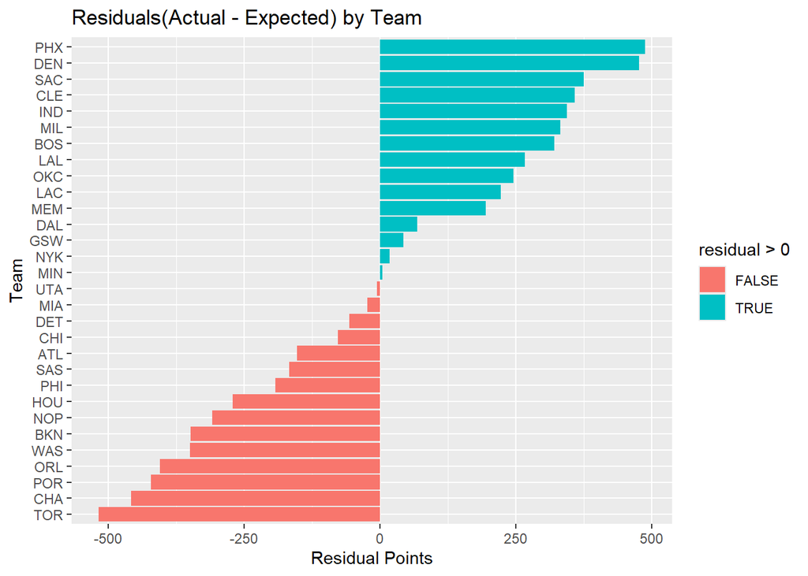

```r
scored_shots = shots_by_ft %>%
  left_join(league_average %>%
              select(distance_ft, SHOT_TYPE, expected_points_league),
            by = c("distance_ft", "SHOT_TYPE"))%>%
  mutate(expected_goal = expected_points_league)

Expected_vs_Actual = scored_shots %>%
  group_by(TEAM_NAME)%>%
  summarize(
    expected_points = sum(expected_goal, na.rm = TRUE),
    actual_points = sum(Points_rule, na.rm = TRUE),
    number_of_shots = n(),
    .groups = "drop"
  )%>%mutate(residual = actual_points - expected_points)


ggplot(Expected_vs_Actual,
       aes(x = reorder(TEAM_NAME, residual),
           y = residual,
           fill = residual > 0))+
  geom_col()+
  coord_flip()+
  labs(title = "Residuals(Actual - Expected) by Team", x = "Team", y = "Residual Points")
```

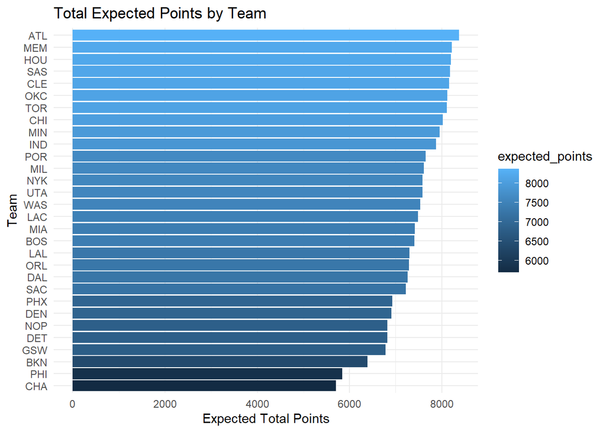

```r
ggplot(Expected_vs_Actual,
       aes(x = reorder(TEAM_NAME, expected_points),
           y = expected_points,
           fill = expected_points))+
  geom_col()+
  coord_flip()+
  labs(title = "Total Expected Points by Team",
       x = "Team",
       y = "Expected Total Points")+
  theme_minimal()
```

```r
league_avearage_2.0 = shots_by_ft %>%
  group_by(distance_ft, SHOT_ZONE_BASIC, SHOT_TYPE)%>%
  summarize(
    attempt_league = n(),
    made_shots_league = sum(SHOT_MADE_FLAG == 1, na.rm = TRUE),
    fg_percentage_league = attempt_league / made_shots_league,
    expected_points_league = mean(Points_rule, na.rm = TRUE)
  )
```

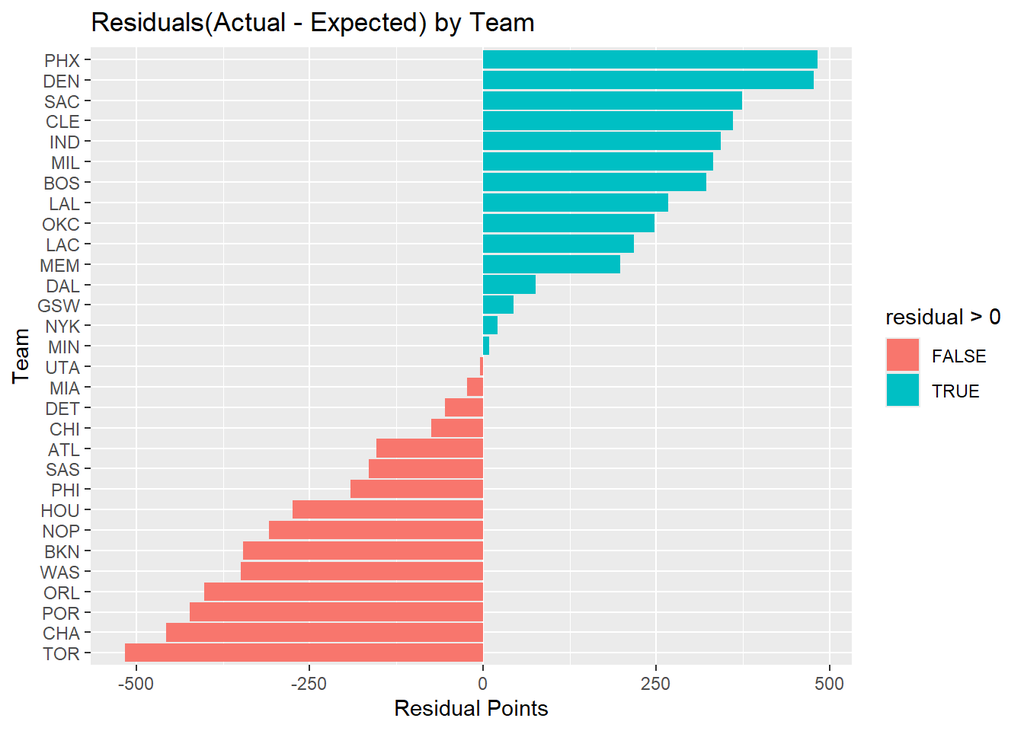

```r
scored_shots_2.0 = shots_by_ft2.0 %>%
  left_join(league_avearage_2.0 %>%
              select(distance_ft, SHOT_ZONE_BASIC, SHOT_TYPE, expected_points_league),
            by = c("distance_ft", "SHOT_ZONE_BASIC", "SHOT_TYPE")) %>%
  mutate(expected_goal = expected_points_league)

Expected_vs_Actual_2.0 = scored_shots_2.0 %>%
  group_by(TEAM_NAME)%>%
  summarize(
    expected_points = sum(expected_goal, na.rm = TRUE),
    actual_points = sum(Points_rule, naa.rm = TRUE),
    number_of_shots = n(),
    .groups = "drop"
  )%>%mutate(residual = actual_points - expected_points)

ggplot(Expected_vs_Actual_2.0,
       aes(x = reorder(TEAM_NAME, residual),
           y = residual,
           fill = residual > 0))+
  geom_col()+
  coord_flip()+
  labs(title = "Residuals(Actual - Expected) by Team",x = "Team", y = "Residual Points")
```

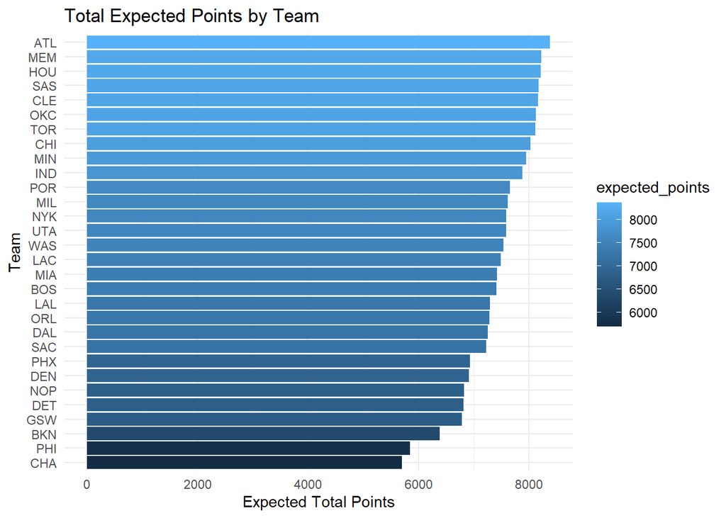

```r
ggplot(Expected_vs_Actual_2.0,
       aes(x = reorder(TEAM_NAME, expected_points),
           y = expected_points,
           fill = expected_points))+
  geom_col()+
  coord_flip()+
  labs(title = "Total Expected Points by Team",
       x = "Team",
       y = "Expected Total Points")+
  theme_minimal()
```

```r
scored_shots_2.0 = scored_shots_2.0 %>% mutate(make_probability = case_when(
  SHOT_TYPE == "2PT Field Goal" ~ expected_goal / 2,
  SHOT_TYPE == "3PT Field Goal" ~ expected_goal / 3
)) %>% mutate(predicted_made = ifelse(make_probability > 0.5, 1, 0))
scored_shots_2.0
```

```
## # A tibble: 204,316 × 14
##    PLAYER_NAME      TEAM_NAME SHOT_DISTANCE SHOT_TYPE      SHOT_ZONE_BASIC   PTS
##    <chr>            <chr>             <dbl> <chr>          <chr>           <dbl>
##  1 Precious Achiuwa NYK                   0 2PT Field Goal Restricted Area     2
##  2 Precious Achiuwa NYK                  23 3PT Field Goal Right Corner 3      0
##  3 Precious Achiuwa NYK                   1 2PT Field Goal Restricted Area     0
##  4 Precious Achiuwa NYK                   0 2PT Field Goal Restricted Area     0
##  5 Precious Achiuwa NYK                   0 2PT Field Goal Restricted Area     2
##  6 Precious Achiuwa NYK                   0 2PT Field Goal Restricted Area     2
##  7 Precious Achiuwa NYK                  10 2PT Field Goal In The Paint (…     0
##  8 Precious Achiuwa NYK                   8 2PT Field Goal In The Paint (…     2
##  9 Precious Achiuwa NYK                   0 2PT Field Goal Restricted Area     2
## 10 Precious Achiuwa NYK                   0 2PT Field Goal Restricted Area     0
## # ℹ 204,306 more rows
## # ℹ 8 more variables: SHOT_MADE_FLAG <dbl>, team_abbreviation <chr>,
## #   Points_rule <dbl>, distance_ft <dbl>, expected_points_league <dbl>,
## #   expected_goal <dbl>, make_probability <dbl>, predicted_made <dbl>
```

### Defensive Evaluation

To evaluate team-level defensive efficiency, we applied the Binning and Averaging model from the defensive perspective. In `shots_defense`, we constructed a defensive dataset by identifying the defending team for each shot using `HTM` (Home Team) and `VTM` (Visiting Team) variables to create an `Opponents` variable. As with the offensive model, observations missing `SHOT_DISTANCE` were filtered out, and `distance_ft` was created by flooring distances to the nearest whole foot.

In `league_average_defense`, shots were grouped by `distance_ft` and `SHOT_TYPE` to compute league-wide defensive expectations. The variable `expected_points_league` measures how many points a league-average defense would allow per attempt from each shot category. This data set was merged back into `scored_shots_defense`, assigning each shot an `expected_goal` representing the expected points an average defense would allow from that location.

Finally, in `Expected_vs_Actual_defense`, values were aggregated by defending team to compare expected and actual points allowed. Residuals (`actual_points_allowed` minus `expected_points_allowed`) quantify defensive over or underperformance. Teams with positive residuals, such as the Utah Jazz and Sacramento Kings, allowed more points than expected due to poor defensive execution, while teams with negative residuals, like the Oklahoma City Thunder and Cleveland Cavaliers, allowed fewer points through elite defense. `expected_points_allowed` reveals shot quality conceded: teams like the Chicago Bulls allowed opponents to generate high-quality shot opportunities, while teams like the Orlando Magic forced opponents into low-quality attempts.

```r
shots_defense = shots_2025_model1.1 %>%
  select(GAME_ID, HTM, VTM, PLAYER_NAME, TEAM_NAME, SHOT_DISTANCE, SHOT_TYPE,
         SHOT_ZONE_BASIC, SHOT_MADE_FLAG, PTS)%>%
  mutate(
    SHOT_DISTANCE = as.numeric(SHOT_DISTANCE),
    Points_rule = case_when(
      SHOT_MADE_FLAG == 1 & SHOT_TYPE == "3PT Field Goal" ~ 3,
      SHOT_MADE_FLAG == 1 & SHOT_TYPE == "2PT Field Goal" ~ 2,
      TRUE ~ 0
         ),
    team_abbreviation = Team_abbreviation[TEAM_NAME],
    Opponents = case_when(
      team_abbreviation == HTM ~ VTM,
      team_abbreviation == VTM ~ HTM,
      TRUE ~ NA_character_
    ))

shots_by_ft_defense = shots_defense%>%
  filter(!is.na(SHOT_DISTANCE))%>%
  mutate(distance_ft = floor(SHOT_DISTANCE))

league_average_defense = shots_by_ft_defense %>%
  group_by(distance_ft, SHOT_TYPE)%>%
  summarize(
    attempt_league = n(),
    made_shots_league = sum(SHOT_MADE_FLAG == 1, na.rm = TRUE),
    fg_percentage_league = attempt_league / made_shots_league,
    expected_points_league = mean(Points_rule, na.rm = TRUE)
  )
```

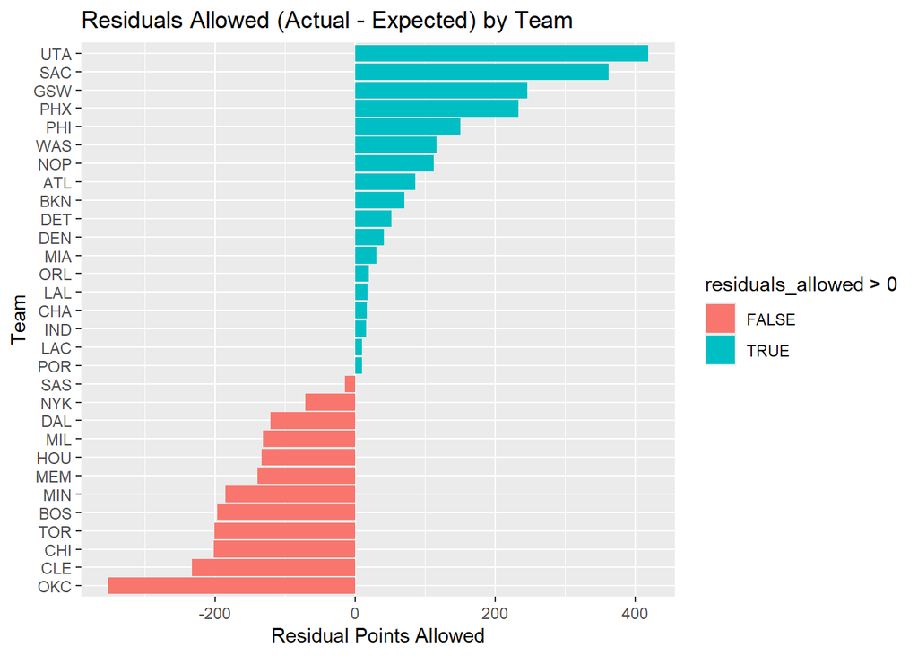

```r
scored_shots_defense = shots_by_ft_defense %>%
  left_join(league_average_defense %>%
              select(distance_ft, SHOT_TYPE, expected_points_league),
            by = c("distance_ft","SHOT_TYPE")) %>%
  mutate(expected_goal = expected_points_league)

Expected_vs_Actual_defense = scored_shots_defense %>%
  group_by(Opponents)%>%
  summarize(
    expected_points_allowed = sum(expected_goal, na.rm = TRUE),
    actual_points_allowed = sum(Points_rule, naa.rm = TRUE),
    number_of_shots_faced = n(),
    .groups = "drop"
  )%>% mutate(residuals_allowed = actual_points_allowed - expected_points_allowed )


ggplot(Expected_vs_Actual_defense,
       aes(x = reorder(Opponents, residuals_allowed),
           y = residuals_allowed,
           fill = residuals_allowed > 0))+
  geom_col()+
  coord_flip()+
  labs(title = "Residuals Allowed (Actual - Expected) by Team",x = "Team", y = "Residual Points Allowed")
```

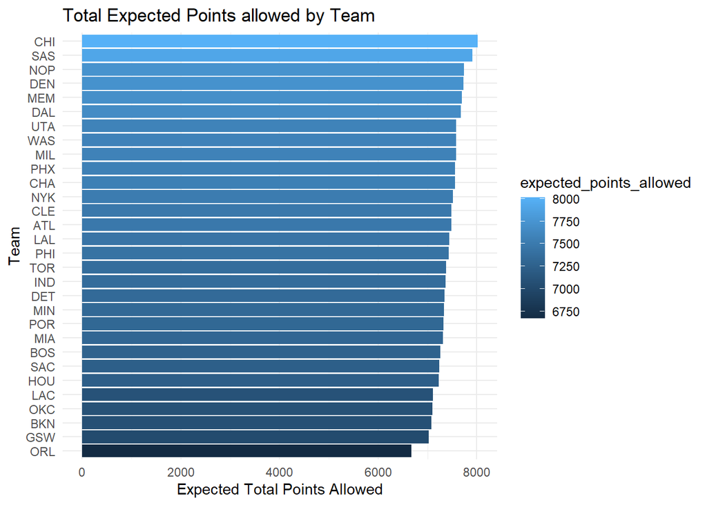

```r
ggplot(Expected_vs_Actual_defense,
       aes(x = reorder(Opponents, expected_points_allowed),
           y = expected_points_allowed,
           fill = expected_points_allowed))+
  geom_col()+
  coord_flip()+
  labs(title = "Total Expected Points allowed by Team",
       x = "Team",
       y = "Expected Total Points Allowed")+
  theme_minimal()
```

### Applications via Pythagorean Expectation

To extend the analysis from expected scoring efficiency to season-level performance, we implemented the Pythagorean Win Expectation model. This model operates on the principle that teams who score more points and allow fewer points tend to win more games, with the ratio of points scored to points allowed providing a strong predictor of overall success.

We began by constructing three data sets: Expected_Offense contains each team’s total expected points scored, Expected_Defense contains total expected points allowed (both from the Binning and Averaging model), and Games_per_team accounts for the number of games each team played. These data sets were merged by team to form Pythagorean_win. We applied the Pythagorean Win formula used by Baseball Reference, calculating win percentage as:

$$\text{Win %} =
\frac{PS^{1.83}}{PS^{1.83} + PA^{1.83}}$$
Where PS represents points scored, and PA represents points allowed.

Results were rounded to whole numbers for interpret ability. The Pythagorean Win projections aligned closely with the Expected Net Points analysis from the combined offense and defense models. Teams like the Oklahoma City Thunder and Houston Rockets, who ranked first and second in expected net points, also projected approximately 46 expected wins in the Pythagorean model. This consistency confirms that net shot quality measured by the Binning and Averaging model translates meaningfully into expected success over an 82-game season. Teams generating more efficient scoring opportunities while preventing opponents from doing the same naturally project higher win totals.

Expected Combined Points by Team

```r
Expected_vs_Actual_2.0 = Expected_vs_Actual_2.0 %>%
  mutate(Team_abbreviation = TEAM_NAME)


Offense_and_Defense = Expected_vs_Actual_2.0 %>%
  select(TEAM_NAME, Team_abbreviation,
         expected_points_scored = expected_points,
         actual_points_scored = actual_points,
         resiudal_scored = residual)%>%
  left_join(
    Expected_vs_Actual_defense%>%
      select(Opponents,
             expected_points_allowed,
             actual_points_allowed,
             residuals_allowed),
    by = c("Team_abbreviation" = "Opponents")) %>%
      mutate(
        expected_combined_points = expected_points_scored - expected_points_allowed,
        actual_combined_points = actual_points_scored - actual_points_allowed,
        residual_combined = resiudal_scored - residuals_allowed
      )
```

```r
Offense_and_Defense
```

```
## # A tibble: 30 × 11
##    TEAM_NAME Team_abbreviation expected_points_scored actual_points_scored
##    <chr>     <chr>                              <dbl>                <dbl>
##  1 ATL       ATL                                8374.                 8220
##  2 BKN       BKN                                6386.                 6040
##  3 BOS       BOS                                7410.                 7733
##  4 CHA       CHA                                5701.                 5245
##  5 CHI       CHI                                8024.                 7949
##  6 CLE       CLE                                8159.                 8520
##  7 DAL       DAL                                7256.                 7332
##  8 DEN       DEN                                6910.                 7387
##  9 DET       DET                                6817.                 6762
## 10 GSW       GSW                                6784.                 6828
## # ℹ 20 more rows
## # ℹ 7 more variables: resiudal_scored <dbl>, expected_points_allowed <dbl>,
## #   actual_points_allowed <dbl>, residuals_allowed <dbl>,
## #   expected_combined_points <dbl>, actual_combined_points <dbl>,
## #   residual_combined <dbl>
```

```r
Offense_and_Defense_rankings = Offense_and_Defense %>% select(TEAM_NAME, expected_combined_points) %>% mutate(Rank_Model1 = min_rank(desc(expected_combined_points)))
Offense_and_Defense_rankings
```

```
## # A tibble: 30 × 3
##    TEAM_NAME expected_combined_points Rank_Model1
##    <chr>                        <dbl>       <int>
##  1 ATL                         889.             3
##  2 BKN                        -693.            26
##  3 BOS                         149.            13
##  4 CHA                       -1854.            30
##  5 CHI                           8.79          17
##  6 CLE                         674.             5
##  7 DAL                        -415.            23
##  8 DEN                        -816.            27
##  9 DET                        -528.            24
## 10 GSW                        -243.            22
## # ℹ 20 more rows
```

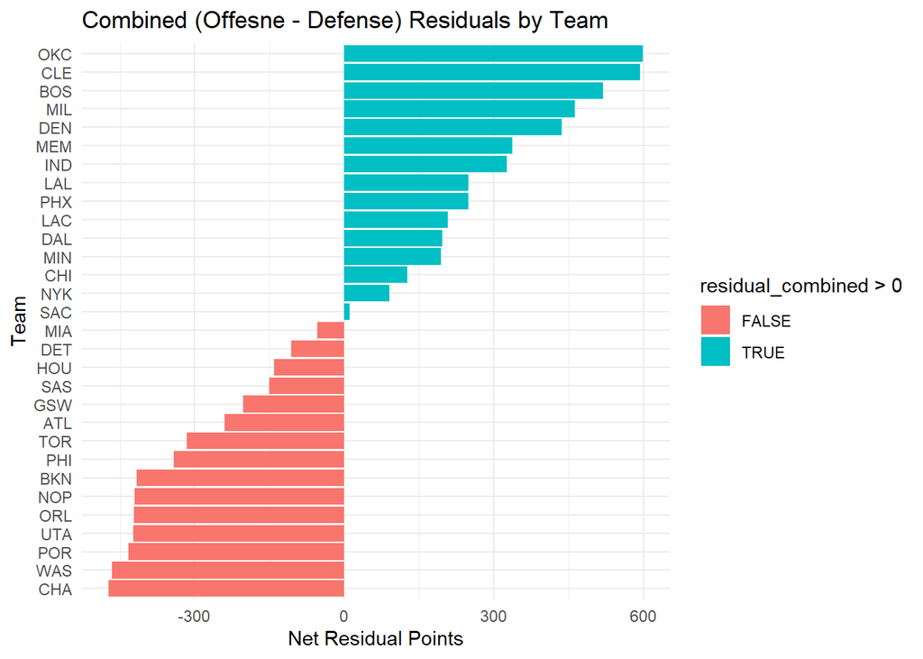

```r
ggplot(Offense_and_Defense,
       aes(x = reorder(TEAM_NAME, residual_combined),
           y = residual_combined,
           fill = residual_combined > 0))+
  geom_col()+
  coord_flip()+
  labs(title = "Combined (Offesne - Defense) Residuals by Team",
       x = "Team",
       y = "Net Residual Points")+
  theme_minimal()
```

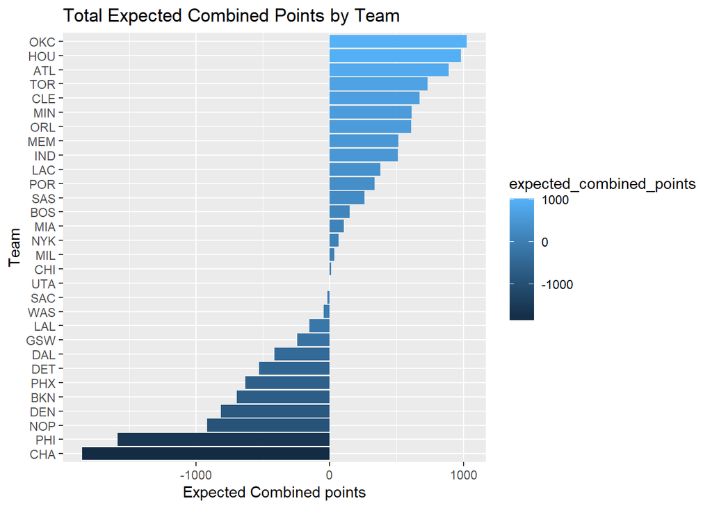

```r
ggplot(Offense_and_Defense,
       aes(x = reorder(TEAM_NAME, expected_combined_points),
           y =  expected_combined_points,
           fill = expected_combined_points))+
  geom_col()+
  coord_flip()+
  labs(title = "Total Expected Combined Points by Team",
       x = "Team",
       y = "Expected Combined points")
```

```r
Expected_Offense = Expected_vs_Actual_2.0 %>%
  select(TEAM_NAME, expected_points_scored = expected_points)

Expected_Defense = Expected_vs_Actual_defense %>%
  select(Opponents, expected_points_allowed) %>% rename(TEAM_NAME = Opponents)

Games_per_team = shots_2025 %>%
  select(TEAM_NAME, GAME_ID) %>%
  distinct() %>%
  count(TEAM_NAME, name = "games")

pythagorean_win = Expected_Offense %>%
  left_join(Expected_Defense, by = "TEAM_NAME") %>%
  left_join(Games_per_team, by = "TEAM_NAME") %>%
  mutate(
    expected_points = expected_points_scored / games,
    expected_points_against = expected_points_allowed / games,
    pythagorean_win_percentage = (expected_points^1.83) /
      ((expected_points^1.83) + (expected_points_against^1.83)),
    expected_wins = pythagorean_win_percentage * games,
    expected_losses = games - expected_wins
  ) %>%
  mutate(
    expected_wins = round(expected_wins),
    expected_losses = round(expected_losses)
  )
```

```r
pythagorean_win
```

```
## # A tibble: 30 × 9
##    TEAM_NAME expected_points_scored expected_points_allo…¹ games expected_points
##    <chr>                      <dbl>                  <dbl> <int>           <dbl>
##  1 ATL                        8374.                  7485.    82           102.
##  2 BKN                        6386.                  7079.    82            77.9
##  3 BOS                        7410.                  7261.    82            90.4
##  4 CHA                        5701.                  7555.    82            69.5
##  5 CHI                        8024.                  8015.    82            97.9
##  6 CLE                        8159.                  7485.    82            99.5
##  7 DAL                        7256.                  7671.    82            88.5
##  8 DEN                        6910.                  7726.    82            84.3
##  9 DET                        6817.                  7344.    82            83.1
## 10 GSW                        6784.                  7027.    82            82.7
## # ℹ 20 more rows
## # ℹ abbreviated name: ¹expected_points_allowed
## # ℹ 4 more variables: expected_points_against <dbl>,
## #   pythagorean_win_percentage <dbl>, expected_wins <dbl>,
## #   expected_losses <dbl>
```

### Model Performance

The model showed a mean Log Loss of 0.683, suggesting that the Pythagorean model using Binning and Averaging provides a reasonable approximation of team success but lacks precision compared to more sophisticated statistical models. The results confirm that scoring and defending efficiencies meaningfully translate into season-level success—teams like the Oklahoma City Thunder and Houston Rockets ranked among the top in both predicted and actual win percentages. However, the model’s limitations reflect missing contextual factors such as free throws, player skill variations, and possession differences, as well as the Binning model’s inherent simplicity and inability to capture nonlinear relationships or interactions between variables like offense and defense.

```r
nba_standings <- tribble(
  ~TEAM_NAME, ~W, ~L, ~WinPct,
  "CLE", 64, 18, 0.780,
  "BOS", 61, 21, 0.744,
  "NYK", 51, 31, 0.622,
  "IND", 50, 32, 0.610,
  "MIL", 48, 34, 0.585,
  "DET", 44, 38, 0.537,
  "ORL", 41, 41, 0.500,
  "ATL", 40, 42, 0.488,
  "CHI", 39, 43, 0.476,
  "MIA", 37, 45, 0.451,
  "TOR", 30, 52, 0.366,
  "BKN", 26, 56, 0.317,
  "PHI", 24, 58, 0.293,
  "CHA", 19, 63, 0.232,
  "WAS", 18, 64, 0.220,
  "OKC", 68, 14, 0.829,
  "HOU", 52, 30, 0.634,
  "LAL", 50, 32, 0.610,
  "DEN", 50, 32, 0.610,
  "LAC", 50, 32, 0.610,
  "MIN", 49, 33, 0.598,
  "GSW", 48, 34, 0.585,
  "MEM", 48, 34, 0.585,
  "SAC", 40, 42, 0.488,
  "DAL", 39, 43, 0.476,
  "PHX", 36, 46, 0.439,
  "POR", 36, 46, 0.439,
  "SAS", 34, 48, 0.415,
  "NOP", 21, 61, 0.256,
  "UTA", 17, 65, 0.207
)
```

### Assessing Model Perforance

```r
Comparison = pythagorean_win %>%
  select(TEAM_NAME, pythagorean_win_percentage) %>%
  left_join(nba_standings, by = c("TEAM_NAME"))%>%
  rename(true_win_percentage = WinPct, predicted_win_percentage = pythagorean_win_percentage)


log_loss_season = logloss(Comparison$true_win_percentage, Comparison$predicted_win_percentage)
log_loss_season
```

```
## [1] 0.6811966
```

```r
set.seed(5)

simulate_score = function(df, games_per_team = 82){
  game_level = df %>%
    tidyr::uncount(games_per_team) %>%
    mutate(actual = rbinom(n(), size = 1, prob = true_win_percentage),
           prediction = pmin(pmax(predicted_win_percentage, 1e-12),1-1e-12),
           each_log_loss = -(actual * log(prediction)+(1-actual)* log(1-prediction))
           )
  tibble(mean_log_loss = mean(game_level$each_log_loss))}

results = bind_rows(
  simulate_score(Comparison),
  simulate_score(Comparison),
  simulate_score(Comparison))

results %>% summarize(average_log_loss = mean(mean_log_loss))
```

```
## # A tibble: 1 × 1
##   average_log_loss
##              <dbl>
## 1            0.683
```

```r
results
```

```
## # A tibble: 3 × 1
##   mean_log_loss
##           <dbl>
## 1         0.683
## 2         0.683
## 3         0.682
```

## Model 2: Logistic Regression

A glaring issue with the naive binning and average model is that it can make estimates on small samples of data. This often occurs when the model uses continuous variables. Additionally, the Naive model “bucketizes” its outcomes; i.e. it cannot make a definitive prediction for each individual shot, only shots of similar features.

In this scenario, a logistic regression model is a good alternative. This is because logistic regression models are fit to the data and can make reasonable estimates for the relationships between continuous variables and the response variable.

**Logistic Model Expression:**

$$\log\left(\frac{\mathbb{P}(Y= 1 \vert
\boldsymbol{\mathbf{X}})}{\mathbb{P}(Y = 0 \vert
\boldsymbol{\mathbf{X}})}\right) = \beta_{0} + \beta_{1}X_{1} + \cdots +
\beta_{p}X_{p}.$$

- Binary Outcome Y (Probability of a shot being made, 1 indicated the shot was made, 0 a miss)
- Variables $X_1, ..., X_p$

**Our Logistic Model:**

Our logistic model is modeling the probability that a shot results in a made basket. It is accounting for several continuous and categorical variables. One nice aspect of the logistic regression model which we laid out above is that it can account for continuous variables. This allows us to add some very important predictors into our model including location (x,y coordinate of the shot) and time (the time remaining in the quarter and the game). We expect intuitively that accounting for these variables will make our model more accurate. Let’s see if this is the case!

Selected variables were also represented as factors as pre-processing, as the logistic regression model must interpret the different verbal entries for certain columns as numbers.

```r
shots_2025_model2 <- shots_2025 %>%
  mutate(SHOT_ID = row_number()) %>%
  mutate(SHOT_TYPE = as.factor(SHOT_TYPE)) %>%
  mutate(ACTION_TYPE = as.factor(ACTION_TYPE)) %>%
  mutate(SHOT_ZONE_BASIC = as.factor(SHOT_ZONE_BASIC)) %>%
  mutate(SHOT_ZONE_AREA = as.factor(SHOT_ZONE_AREA)) %>%
  mutate(SHOT_ZONE_RANGE = as.factor(SHOT_ZONE_RANGE)) %>%
  mutate(POSSIBLE_POINTS = case_when(
    SHOT_TYPE == "2PT Field Goal" ~ 2,
    SHOT_TYPE == "3PT Field Goal" ~ 3
  ))
shots_2025_model2
```

```
## # A tibble: 204,316 × 31
##    GRID_TYPE       GAME_ID GAME_EVENT_ID PLAYER_ID PLAYER_NAME TEAM_ID TEAM_NAME
##    <chr>             <dbl>         <dbl>     <dbl> <chr>         <dbl> <chr>
##  1 Shot Chart Det…  2.24e7           484   1630173 Precious A…  1.61e9 NYK
##  2 Shot Chart Det…  2.24e7           584   1630173 Precious A…  1.61e9 NYK
##  3 Shot Chart Det…  2.24e7           590   1630173 Precious A…  1.61e9 NYK
##  4 Shot Chart Det…  2.24e7           592   1630173 Precious A…  1.61e9 NYK
##  5 Shot Chart Det…  2.24e7           235   1630173 Precious A…  1.61e9 NYK
##  6 Shot Chart Det…  2.24e7           361   1630173 Precious A…  1.61e9 NYK
##  7 Shot Chart Det…  2.24e7           381   1630173 Precious A…  1.61e9 NYK
##  8 Shot Chart Det…  2.24e7            81   1630173 Precious A…  1.61e9 NYK
##  9 Shot Chart Det…  2.24e7           101   1630173 Precious A…  1.61e9 NYK
## 10 Shot Chart Det…  2.24e7           129   1630173 Precious A…  1.61e9 NYK
## # ℹ 204,306 more rows
## # ℹ 24 more variables: OPPOSING_TEAM_NAME <chr>, PERIOD <dbl>,
## #   MINUTES_REMAINING <dbl>, SECONDS_REMAINING <dbl>, QUARTER_TIME_LEFT <dbl>,
## #   GAME_TIME_LEFT <dbl>, EVENT_TYPE <chr>, ACTION_TYPE <fct>, SHOT_TYPE <fct>,
## #   SHOT_ZONE_BASIC <fct>, SHOT_ZONE_AREA <fct>, SHOT_ZONE_RANGE <fct>,
## #   SHOT_DISTANCE <dbl>, LOC_X <dbl>, LOC_Y <dbl>, SHOT_ATTEMPTED_FLAG <dbl>,
## #   SHOT_MADE_FLAG <dbl>, PTS <dbl>, GAME_DATE <chr>, HTM <chr>, VTM <chr>, …
```

### Building the Logistic Model

To build our logistic model, we used the `glm()` function in R. This allowed us to fit a logistic linear model to the data.

After training our model, we used it to estimate the probability that a shot results in a made basket. We made predictions for every field goal attempted in the 2024-25 season. These predictions were made with the help of R’s predict function and were loaded into a vector which we added to our main shots data frame.

```r
# n_sims was reduced from 100, as 100 was far too slow and took up too much memory due to the size of the data set
n_sims2 <- 2

## Initialize training and testing log loss vectors
train_logloss2 <- rep(NA, times = n_sims2)
test_logloss2 <- rep(NA, times = n_sims2)

## Set our training df to be 75% of the full df
n_row2 <- nrow(shots_2025_model2)
n_train2 <- floor(0.75 * n_row2)

## Create training-testing splits
for(r in 1:n_sims2){
  set.seed(479 + r)

  train_data2 <- shots_2025_model2 |> dplyr::slice_sample(n = n_train2)
  test_data2 <- shots_2025_model2 |> dplyr::anti_join(y = train_data2, by = "SHOT_ID")

  fit2 <- glm(
    formula = SHOT_MADE_FLAG ~ PERIOD + MINUTES_REMAINING + SECONDS_REMAINING + QUARTER_TIME_LEFT + GAME_TIME_LEFT + ACTION_TYPE + SHOT_TYPE + SHOT_ZONE_RANGE + SHOT_ZONE_AREA + SHOT_ZONE_BASIC + SHOT_DISTANCE + LOC_X + LOC_Y,
    data = train_data2,
    family = binomial("logit")
  )

  ## Predict probabilities
  train_preds2 <- suppressWarnings(predict(object = fit2, newdata = train_data2, type = "response"))
  test_preds2 <- suppressWarnings(predict(object = fit2, newdata = test_data2, type = "response"))
  train_preds2_log = train_preds2
  test_preds2_log = test_preds2

  ## Convert probabilities to expected points
  train_data2$train_probs2 <- train_preds2
  train_data2 <- train_data2 %>% mutate(EXPECTED_POINTS2 = train_preds2 * POSSIBLE_POINTS)

  test_data2$test_probs2 <- test_preds2
  test_data2 <- test_data2 %>% mutate(EXPECTED_POINTS2 = test_preds2 * POSSIBLE_POINTS)

  ## Compute log loss
  train_logloss2[r] <- logloss(train_data2$SHOT_MADE_FLAG, train_preds2_log)
  test_logloss2[r] <- logloss(test_data2$SHOT_MADE_FLAG, test_preds2_log)
}
## Print average log loss
```

```r
cat("Logistic Regression Training Logloss:", round(mean(train_logloss2), digits = 3), "\n")
```

```
## Logistic Regression Training Logloss: 0.641
```

```r
cat("Logistic Regression T Logloss:", round(mean(test_logloss2), digits = 3), "\n")
```

```
## Logistic Regression T Logloss: 0.642
```

```r
model2_train_log_loss = round(mean(train_logloss2), digits = 3)
model2_test_log_loss = round(mean(test_logloss2), digits = 3)
```

```r
set.seed(479)

## Train model on full dataset
full_df_fit2 <- glm(
  formula = SHOT_MADE_FLAG ~ PERIOD + MINUTES_REMAINING + SECONDS_REMAINING + QUARTER_TIME_LEFT + GAME_TIME_LEFT + ACTION_TYPE + SHOT_TYPE + SHOT_ZONE_RANGE + SHOT_ZONE_AREA + SHOT_ZONE_BASIC + SHOT_DISTANCE + LOC_X + LOC_Y,
  data = shots_2025,
  family = binomial("logit")
)

## Predict probabilities
probability_preds2 <- suppressWarnings(predict(object = full_df_fit2, newdata = shots_2025, type = "response"))

## Append predictions and compute expected points
```

### Building the Expected Points Model:

After assigning a probability to every field goal in the dataframe, we are ready to build an expected points model. Our expected points predictions for each shot is simply computed by multiplying the probability (that the shot is made) by the amount of points the shot is worth.

$$E[X_i] = p_i \times Z_i$$

where

- $X_i$; $i = 1, 2, ..., n$ is the amount of points scored from the $i$th shot
- $p_i$; $i = 1, 2, ..., n$ is the probability that the $i$th shot is made
- $Z_i$; $i = 1, 2, ..., n$ is the number of points the $i$th shot is worth

For example, a 2 point field goal attempt with a 50% probability of going in the basket has an expected points of 1.

```r
shots_2025_xp2 <- shots_2025_model2 %>%
  mutate(EXPECTED_PROBABILITY = probability_preds2) %>%
  mutate(EXPECTED_POINTS = EXPECTED_PROBABILITY * POSSIBLE_POINTS)
```

### Team Summary Tables

After building an expected points model which assigns an expected point value to every field goal from the 2024-25 season, our goal was to compute summary statistics for the expected points scored and allowed for each team.

This was done via a `group_by` –> `summarize` command to group shots according to the team the shot-taker was playing for and against. We created two intermediate tables (one for expected points scored and one for expected points allowed) and then merged them into a combined data frame.

```r
shots_2025_xp2 = shots_2025_xp2 %>% mutate(PREDICTED_MADE = ifelse(EXPECTED_PROBABILITY > 0.5, 1, 0))
shots_2025_xp2
```

```
## # A tibble: 204,316 × 34
##    GRID_TYPE       GAME_ID GAME_EVENT_ID PLAYER_ID PLAYER_NAME TEAM_ID TEAM_NAME
##    <chr>             <dbl>         <dbl>     <dbl> <chr>         <dbl> <chr>
##  1 Shot Chart Det…  2.24e7           484   1630173 Precious A…  1.61e9 NYK
##  2 Shot Chart Det…  2.24e7           584   1630173 Precious A…  1.61e9 NYK
##  3 Shot Chart Det…  2.24e7           590   1630173 Precious A…  1.61e9 NYK
##  4 Shot Chart Det…  2.24e7           592   1630173 Precious A…  1.61e9 NYK
##  5 Shot Chart Det…  2.24e7           235   1630173 Precious A…  1.61e9 NYK
##  6 Shot Chart Det…  2.24e7           361   1630173 Precious A…  1.61e9 NYK
##  7 Shot Chart Det…  2.24e7           381   1630173 Precious A…  1.61e9 NYK
##  8 Shot Chart Det…  2.24e7            81   1630173 Precious A…  1.61e9 NYK
##  9 Shot Chart Det…  2.24e7           101   1630173 Precious A…  1.61e9 NYK
## 10 Shot Chart Det…  2.24e7           129   1630173 Precious A…  1.61e9 NYK
## # ℹ 204,306 more rows
## # ℹ 27 more variables: OPPOSING_TEAM_NAME <chr>, PERIOD <dbl>,
## #   MINUTES_REMAINING <dbl>, SECONDS_REMAINING <dbl>, QUARTER_TIME_LEFT <dbl>,
## #   GAME_TIME_LEFT <dbl>, EVENT_TYPE <chr>, ACTION_TYPE <fct>, SHOT_TYPE <fct>,
## #   SHOT_ZONE_BASIC <fct>, SHOT_ZONE_AREA <fct>, SHOT_ZONE_RANGE <fct>,
## #   SHOT_DISTANCE <dbl>, LOC_X <dbl>, LOC_Y <dbl>, SHOT_ATTEMPTED_FLAG <dbl>,
## #   SHOT_MADE_FLAG <dbl>, PTS <dbl>, GAME_DATE <chr>, HTM <chr>, VTM <chr>, …
```

This resulted in a neat summary table. It compares our model’s predicted expected total points (scored and allowed) with the actual points scored and allowed by every team in the league.

```r
## Team Summary Table - Expected Points Scored
team_xp_scored2 <- shots_2025_xp2 %>%
  group_by(TEAM_NAME) %>%
  summarize(
    TOTAL_POINTS = sum(PTS),
    EXPECTED_TOTAL_POINTS = sum(EXPECTED_POINTS),
    FGA = sum(SHOT_ATTEMPTED_FLAG),
    POINTS_PER_100 = (TOTAL_POINTS / FGA) * 100,
    EXPECTED_POINTS_PER_100 = (EXPECTED_TOTAL_POINTS / FGA) * 100
  )

## Team Summary Table - Expected Points Allowed
team_xp_allowed2 <- shots_2025_xp2 %>%
  group_by(OPPOSING_TEAM_NAME) %>%
  summarize(
    TOTAL_POINTS_ALLOWED = sum(PTS),
    EXPECTED_TOTAL_POINTS_ALLOWED = sum(EXPECTED_POINTS),
    FG_ALLOWED = sum(SHOT_ATTEMPTED_FLAG),
    POINTS_ALLOWED_PER_100 = (TOTAL_POINTS_ALLOWED / FG_ALLOWED) * 100,
    EXPECTED_POINTS_ALLOWED_PER_100 = (EXPECTED_TOTAL_POINTS_ALLOWED / FG_ALLOWED) * 100
  ) %>%
  rename(TEAM_NAME = OPPOSING_TEAM_NAME)

team_xp_combined2 <- merge(team_xp_scored2, team_xp_allowed2, by = "TEAM_NAME") %>%
  mutate(TOTAL_POINT_DIFF = TOTAL_POINTS - TOTAL_POINTS_ALLOWED) %>%
  mutate(EXPECTED_POINT_DIFF = EXPECTED_TOTAL_POINTS - EXPECTED_TOTAL_POINTS_ALLOWED) %>%
  mutate(RESIDUAL_POINT_DIFF = TOTAL_POINT_DIFF - EXPECTED_POINT_DIFF)
```

```r
team_xp_scored2$RESIDUAL_TOTAL_POINTS = team_xp_scored2$TOTAL_POINTS - team_xp_scored2$EXPECTED_TOTAL_POINTS
team_xp_scored2
```

```
## # A tibble: 30 × 7
##    TEAM_NAME TOTAL_POINTS EXPECTED_TOTAL_POINTS   FGA POINTS_PER_100
##    <chr>            <dbl>                 <dbl> <dbl>          <dbl>
##  1 ATL               8219                 8342.  7528           109.
##  2 BKN               6039                 6359.  5800           104.
##  3 BOS               7732                 7357.  6867           113.
##  4 CHA               5244                 5634.  5192           101.
##  5 CHI               7948                 7909.  7176           111.
##  6 CLE               8519                 8118.  7351           116.
##  7 DAL               7331                 7282.  6711           109.
##  8 DEN               7386                 7022.  6363           116.
##  9 DET               6761                 6896.  6235           108.
## 10 GSW               6827                 6841.  6352           107.
## # ℹ 20 more rows
## # ℹ 2 more variables: EXPECTED_POINTS_PER_100 <dbl>,
## #   RESIDUAL_TOTAL_POINTS <dbl>
```

```r
team_xp_combined2_rankings = team_xp_combined2 %>% select(TEAM_NAME, EXPECTED_POINT_DIFF) %>% mutate(Rank_Model2 = min_rank(desc(EXPECTED_POINT_DIFF)))
team_xp_combined2_rankings
```

```
##    TEAM_NAME EXPECTED_POINT_DIFF Rank_Model2
## 1        ATL          900.998044           3
## 2        BKN         -765.922755          27
## 3        BOS          152.134365          13
## 4        CHA        -1877.814680          30
## 5        CHI          -15.343691          18
## 6        CLE          739.751973           5
## 7        DAL         -405.784270          23
## 8        DEN         -759.405462          26
## 9        DET         -467.376929          24
## 10       GSW         -243.246285          22
## 11       HOU         1003.288318           2
## 12       IND          508.340184           8
## 13       LAC          370.468407          10
## 14       LAL         -110.555185          20
```

[output cut: 16 more lines]

```r
team_xp_combined2
```

```
##    TEAM_NAME TOTAL_POINTS EXPECTED_TOTAL_POINTS  FGA POINTS_PER_100
## 1        ATL         8219              8341.586 7528       109.1791
## 2        BKN         6039              6358.731 5800       104.1207
## 3        BOS         7732              7356.778 6867       112.5965
## 4        CHA         5244              5633.908 5192       101.0015
## 5        CHI         7948              7908.661 7176       110.7581
## 6        CLE         8519              8118.475 7351       115.8890
## 7        DAL         7331              7282.455 6711       109.2386
## 8        DEN         7386              7021.850 6363       116.0773
## 9        DET         6761              6895.533 6235       108.4362
## 10       GSW         6827              6840.891 6352       107.4780
## 11       HOU         7932              8209.461 7580       104.6438
## 12       IND         8221              7908.863 7315       112.3855
## 13       LAC         7703              7517.183 6959       110.6912
## 14       LAL         7561              7348.246 6737       112.2310
```

[output cut: 109 more lines]

### Expected Point Differential vs Actual Point Differential

To compare our model’s predictions for team performance with actual results, we created three charts to contrast our expected point differential predictions with the actual point differentials for each NBA team in the 2024-25 season. The final chart is the residual values between expected and actual point differentials, i.e. a metric to quantify which teams are over and under performing.

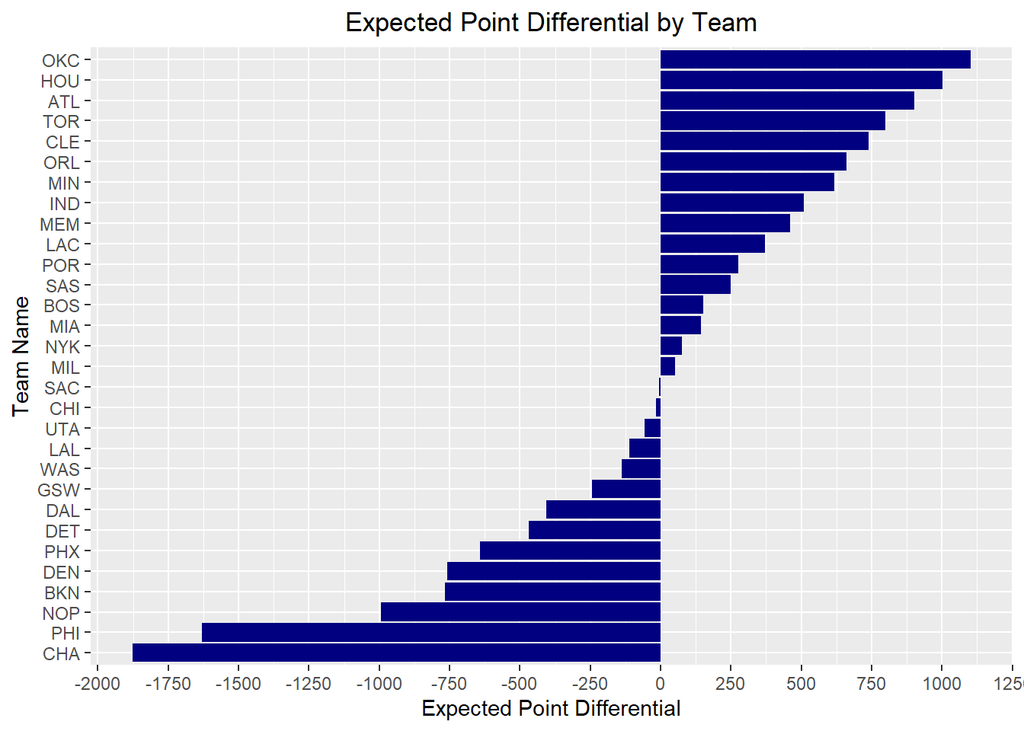

```r
## Expected vs Actual Point Differential
expected_point_diff2 <- ggplot(team_xp_combined2) +
  geom_col(aes(x = EXPECTED_POINT_DIFF, y = reorder(TEAM_NAME, EXPECTED_POINT_DIFF)), fill = "navy") +
  xlab("Expected Point Differential") + ylab("Team Name") +
  scale_x_continuous(breaks = seq(-2000, 1500, 250)) +
  ggtitle("Expected Point Differential by Team") +
  theme(plot.title = element_text(hjust = 0.5))

actual_point_diff2 <- ggplot(team_xp_combined2) +
  geom_col(aes(x = TOTAL_POINT_DIFF, y = reorder(TEAM_NAME, TOTAL_POINT_DIFF)), fill = "navy") +
  xlab("Actual Point Differential") + ylab("Team Name") +
  scale_x_continuous(breaks = seq(-2000, 1500, 250)) +
  ggtitle("Actual Point Differential by Team") +
  theme(plot.title = element_text(hjust = 0.5))

residual_point_diff2 <- ggplot(team_xp_combined2) +
  geom_col(aes(x = RESIDUAL_POINT_DIFF, y = reorder(TEAM_NAME, RESIDUAL_POINT_DIFF)), fill = "navy") +
  xlab("Residual Point Differential") + ylab("Team Name") +
  scale_x_continuous(breaks = seq(-2000, 1500, 250)) +
  ggtitle("Residual (Actual - Expected) Point Differential by Team") +
  theme(plot.title = element_text(hjust = 0.5))

expected_point_diff2
```

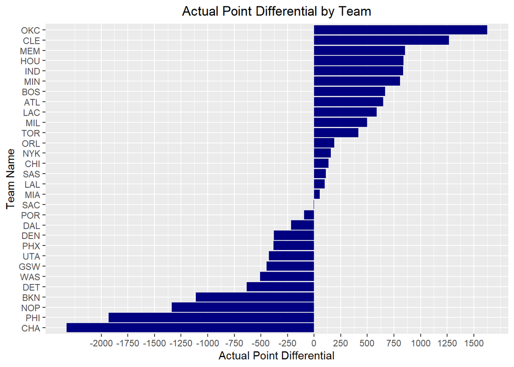

```r
actual_point_diff2
```

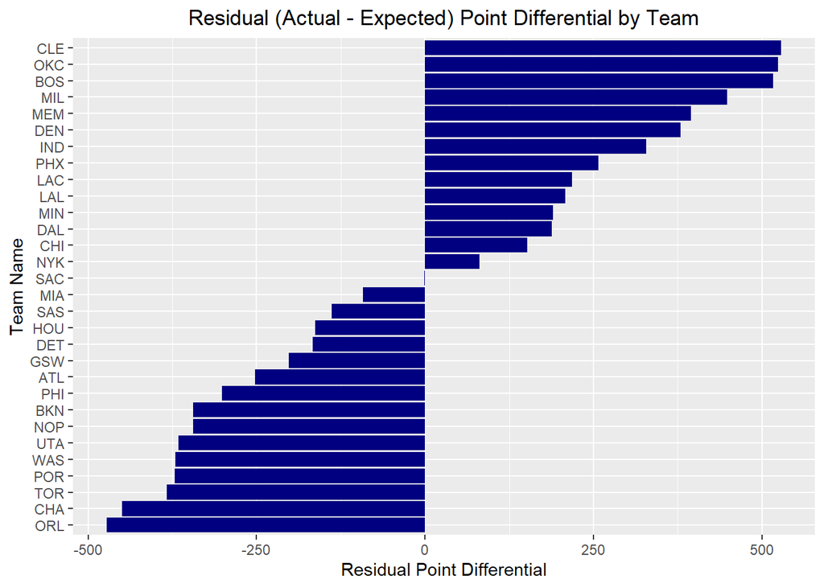

```r
residual_point_diff2
```

### Assessing Model Accuracy

Lastly, we assess the accuracy of our logistic regression model.

We use log-loss to assess our model’s accuracy at predicting probabilities of shots being made. To compute log-loss, we first defined an intermediate function in R. Then, we created 2 training-testing splits (75%/25% training-test split). For each split, we trained the model using the training data and made predictions on the testing data. We then computed log-loss on the training and testing sets and averaged the estimates over the two splits. These values will be of greater importance when comparing performance between models later in the analysis.

```r
cat("Model 2 Training Logloss:", round(mean(train_logloss2), digits = 3), "\n")
```

```
## Model 2 Training Logloss: 0.641
```

```r
cat("Model 2 Testing Logloss:", round(mean(test_logloss2), digits = 3), "\n")
```

```
## Model 2 Testing Logloss: 0.642
```

## Model 3: Random Forests and Feature Analysis

A natural question concerning the evaluation of high-dimensional, complex data is how the many features interact with each other. While it seems natural to keep fitting logistic regression models, it becomes incredibly complex to specify these interactions between continuous, discrete, and categorical factors. Random Forest models simplify these calculations by representing these interactions as an ensemble of randomized regression trees, hence making a forest. The predictive results from these trees are then averaged to produce a probabilistic result. Fitting a random forest model for this particular data set is particularly complex, with the primary reason being the sheer size of the data. 204,316 field goal attempts were recorded in the 2024-25 NBA season, and running the typical 100 train/test splits yielded in memory overload. Thus, the model was trained on a single train/test split, which may yield in over fitting and bias. However, since Random Forest models are known for their ability to reduce over fit, and given that the data set is so large, this problem could be understated.

### Pre-Processing

Several pre-processing steps were taken, which are listed in detail in the following chunks.

```r
# eval = FALSE to save memory when knit, variables are loaded
n = nrow(shots_2025)
n_train = floor(0.75 * n)
n_test = n - n_train

vars = c("PTS", "PERIOD", "MINUTES_REMAINING", "SECONDS_REMAINING",
         "QUARTER_TIME_LEFT", "GAME_TIME_LEFT", "ACTION_TYPE", "SHOT_TYPE",
         "SHOT_ZONE_BASIC", "SHOT_ZONE_AREA", "SHOT_ZONE_RANGE",
         "SHOT_DISTANCE", "LOC_X", "LOC_Y")

shots_2025_forest = shots_2025 %>% mutate(
  ACTION_TYPE = factor(ACTION_TYPE), # factor columns numerically since this is a classification problem
  SHOT_TYPE = factor(SHOT_TYPE),
  SHOT_ZONE_BASIC = factor(SHOT_ZONE_BASIC),
  SHOT_ZONE_AREA = factor(SHOT_ZONE_AREA),
  SHOT_ZONE_RANGE = factor(SHOT_ZONE_RANGE),
  MADE = factor(ifelse(PTS > 0, 1, 0), levels = c(0, 1))
)
```

### Fitting the Model

The Model was then trained and fit on the data, while log loss was recorded to measure statistical accuracy.

```r
# eval = FALSE to save memory when knit, variables are loaded

# n_runs was reduced from 100, as 100 was far too slow and took up too much memory due to the size of the data set
n_runs = 1
train_logloss <- rep(NA, times = n_runs)
test_logloss <- rep(NA, times = n_runs)

for (r in 1:n_runs){
  set.seed(479+r)

  # Split data
  train_data =
    shots_2025_forest %>%
    slice_sample(n = n_train) %>%
    dplyr::select(dplyr::all_of(c("row_id", vars, "MADE")))

  test_data =
    shots_2025_forest %>%
    anti_join(y = train_data, by = "row_id") %>%
    dplyr::select(dplyr::all_of(c("row_id", vars, "MADE")))

  # Extract actual values (0 = miss, 1 = made)
  made_train = as.numeric(as.character(train_data$MADE))
  made_test = as.numeric(as.character(test_data$MADE))

  # Remove row_id and PTS from training data
  train_data = train_data %>% select(-row_id, -PTS)
  test_data = test_data %>% select(-row_id, -PTS)

  # Fit random forest
  fit = ranger::ranger(
    formula = MADE ~ .,
    data = train_data,
    probability = TRUE,
    importance = "permutation")

  # Get predictions (probability of made shot)
  train_preds = predict(object = fit, data = train_data)$predictions[,2]
  test_preds = predict(object = fit, data = test_data)$predictions[,2]

  # Calculate log loss
  train_logloss[r] = logloss(made_train, train_preds)
  test_logloss[r] = logloss(made_test, test_preds)

  full_data = shots_2025_forest %>% select(-row_id, -PTS)

  # Apply model to entire data set
  full_data_predictions = predict(object = fit, data = full_data)$predictions[,2]

  # Produce data set with probabilities and if the shot was made
  shots_2025_with_predicted_shots = shots_2025 %>% mutate(
    PREDICTED_PROB_MADE = full_data_predictions,
    PREDICTED_MADE = ifelse(full_data_predictions > 0.5, 1, 0),
  )
}
```

```r
# Load all the saved RF model results on local machine to save memory
shots_2025_with_predicted_shots <- readRDS("shots_2025_with_predicted_shots.rds")
fit <- readRDS("rf_model.rds")
train_logloss <- readRDS("train_logloss.rds")
test_logloss <- readRDS("test_logloss.rds")
```

The data was then given appropriate values for expected points, equivalent to the predicted probability of the shot resulting in a success, multiplied by the value of the attempted shot.

```r
shots_2025_with_predicted_shots = shots_2025_with_predicted_shots %>%  mutate(EXPECTED_POINTS = case_when(
  SHOT_TYPE == "2PT Field Goal" ~ PREDICTED_PROB_MADE * 2,
  SHOT_TYPE == "3PT Field Goal" ~ PREDICTED_PROB_MADE * 3,
  TRUE ~ 0
))
```

To save computation on the initial local device, the results of the Random Forest Model were saved and loaded to avoid the lengthy process of re-running the model.

```r
saveRDS(shots_2025_with_predicted_shots, "shots_2025_with_predicted_shots.rds")
saveRDS(fit, "rf_model.rds")
saveRDS(train_logloss, "train_logloss.rds")
saveRDS(test_logloss, "test_logloss.rds")
```

```r
# Load all the saved RF model results (note this step was already run, but for the sake of avoiding refitting the model locally)
shots_2025_with_predicted_shots <- readRDS("shots_2025_with_predicted_shots.rds")
fit <- readRDS("rf_model.rds")
train_logloss <- readRDS("train_logloss.rds")
test_logloss <- readRDS("test_logloss.rds")
```

Here we evaluate the importance of each feature in the Random Forest Model. The selected method of quantifying feature importance is known as permutation importance, which quantifies the impact of a particular feature by measuring how much the model’s score drops when that feature’s values are shuffled randomly. For example, the importance plot shows shot distance as the most important of the features, meaning that when the shot distances are shuffled, the model predicts probabilities far less accurately.

```r
importance = fit$variable.importance
importance_frame = data.frame(
  Variable = names(importance),
  Importance = as.numeric(importance)
)
```

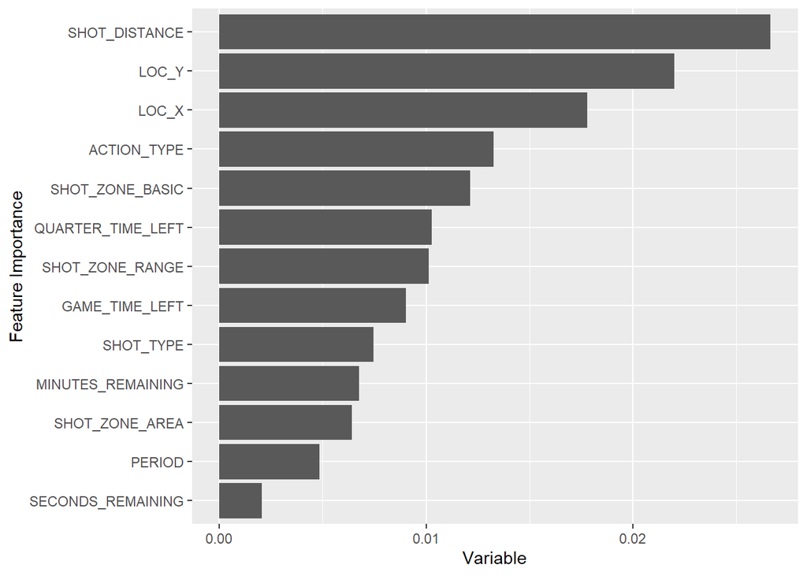

```r
ggplot(importance_frame, aes(x = reorder(Variable, Importance), y = Importance)) + geom_bar(stat = "identity") + coord_flip() + labs(x = "Feature Importance", y = "Variable")
```

### Team Results

After building the expected points model which assigns an expected point value to every field goal from the 2024-25 season, our goal was to compute summary statistics for the expected points scored and allowed for each team.

To provide a general view of the results, a series of summary statistics were generated for both each offense and defense.

```r
team_offensive_stats = shots_2025_with_predicted_shots %>% group_by(TEAM_NAME) %>% summarize(
  TOTAL_POINTS = sum(PTS),
  EXPECTED_TOTAL_POINTS = sum(EXPECTED_POINTS),
  FGA = n(),
  POINTS_PER_100 = (TOTAL_POINTS/FGA) * 100,
  EXPECTED_POINTS_PER_100 = (EXPECTED_TOTAL_POINTS/FGA) * 100
  )

team_defensive_stats = shots_2025_with_predicted_shots %>% group_by(OPPOSING_TEAM_NAME) %>% summarize(
  TOTAL_POINTS_ALLOWED = sum(PTS),
  EXPECTED_TOTAL_POINTS_ALLOWED = sum(EXPECTED_POINTS),
  FGA_ALLOWED = n(),
  POINTS_PER_100_ALLOWED = (TOTAL_POINTS_ALLOWED/FGA_ALLOWED) * 100,
  EXPECTED_POINTS_PER_100_ALLOWED = (EXPECTED_TOTAL_POINTS_ALLOWED/FGA_ALLOWED) * 100
)
team_stats = team_offensive_stats %>% left_join(team_defensive_stats, by = c("TEAM_NAME" = "OPPOSING_TEAM_NAME"))
team_stats = team_stats %>% mutate(
  POINTS_DIFFERENCE = TOTAL_POINTS - TOTAL_POINTS_ALLOWED,
  EXPECTED_POINTS_DIFFERENCE = EXPECTED_TOTAL_POINTS - EXPECTED_TOTAL_POINTS_ALLOWED,
  PER_100_DIFFERENCE = POINTS_PER_100 - POINTS_PER_100_ALLOWED,
  EXPECTED_PER_100_DIFFERENCE = EXPECTED_POINTS_PER_100 - EXPECTED_POINTS_PER_100_ALLOWED,
  POINTS_RESIDUAL = POINTS_DIFFERENCE - EXPECTED_POINTS_DIFFERENCE
)
team_stats
```

```
## # A tibble: 30 × 16
##    TEAM_NAME TOTAL_POINTS EXPECTED_TOTAL_POINTS   FGA POINTS_PER_100
##    <chr>            <dbl>                 <dbl> <int>          <dbl>
##  1 ATL               8219                 8408.  7528           109.
##  2 BKN               6039                 6296.  5800           104.
##  3 BOS               7732                 7468.  6867           113.
##  4 CHA               5244                 5587.  5192           101.
##  5 CHI               7948                 8010.  7176           111.
##  6 CLE               8519                 8318.  7351           116.
##  7 DAL               7331                 7315.  6711           109.
##  8 DEN               7386                 7060.  6363           116.
##  9 DET               6761                 6810.  6235           108.
## 10 GSW               6827                 6855.  6352           107.
## # ℹ 20 more rows
## # ℹ 11 more variables: EXPECTED_POINTS_PER_100 <dbl>,
## #   TOTAL_POINTS_ALLOWED <dbl>, EXPECTED_TOTAL_POINTS_ALLOWED <dbl>,
## #   FGA_ALLOWED <int>, POINTS_PER_100_ALLOWED <dbl>,
## #   EXPECTED_POINTS_PER_100_ALLOWED <dbl>, POINTS_DIFFERENCE <dbl>,
## #   EXPECTED_POINTS_DIFFERENCE <dbl>, PER_100_DIFFERENCE <dbl>,
## #   EXPECTED_PER_100_DIFFERENCE <dbl>, POINTS_RESIDUAL <dbl>
```

```r
team_stats_rankings = team_stats %>% select(TEAM_NAME, EXPECTED_POINTS_DIFFERENCE) %>% mutate(Rank_Model3 = min_rank(desc(EXPECTED_POINTS_DIFFERENCE)))
```

```r
team_stats_final = team_stats %>% mutate(
  TOTAL_POINT_DIFF = TOTAL_POINTS - TOTAL_POINTS_ALLOWED,
  EXPECTED_POINT_DIFF = EXPECTED_TOTAL_POINTS - EXPECTED_TOTAL_POINTS_ALLOWED,
  RESIDUAL_POINT_DIFF = TOTAL_POINT_DIFF - EXPECTED_POINT_DIFF) %>% select(TEAM_NAME, TOTAL_POINT_DIFF, EXPECTED_POINT_DIFF, RESIDUAL_POINT_DIFF)
team_stats_final
```

```
## # A tibble: 30 × 4
##    TEAM_NAME TOTAL_POINT_DIFF EXPECTED_POINT_DIFF RESIDUAL_POINT_DIFF
##    <chr>                <dbl>               <dbl>               <dbl>
##  1 ATL                    649             869.                 -220.
##  2 BKN                  -1110            -806.                 -304.
##  3 BOS                    669             277.                  392.
##  4 CHA                  -2327           -2001.                 -326.
##  5 CHI                    136               0.575               135.
##  6 CLE                   1268             862.                  406.
##  7 DAL                   -218            -343.                  125.
##  8 DEN                   -380            -680.                  300.
##  9 DET                   -634            -546.                  -87.6
## 10 GSW                   -445            -250.                 -195.
## # ℹ 20 more rows
```

The expected and actual points differential for each team were then visualized, as well as its residual values. These residual values both serve as a measurement of how close the model was to estimating each team’s point differential values, as well as a sign if a team is over or under performing relative to these expectations.

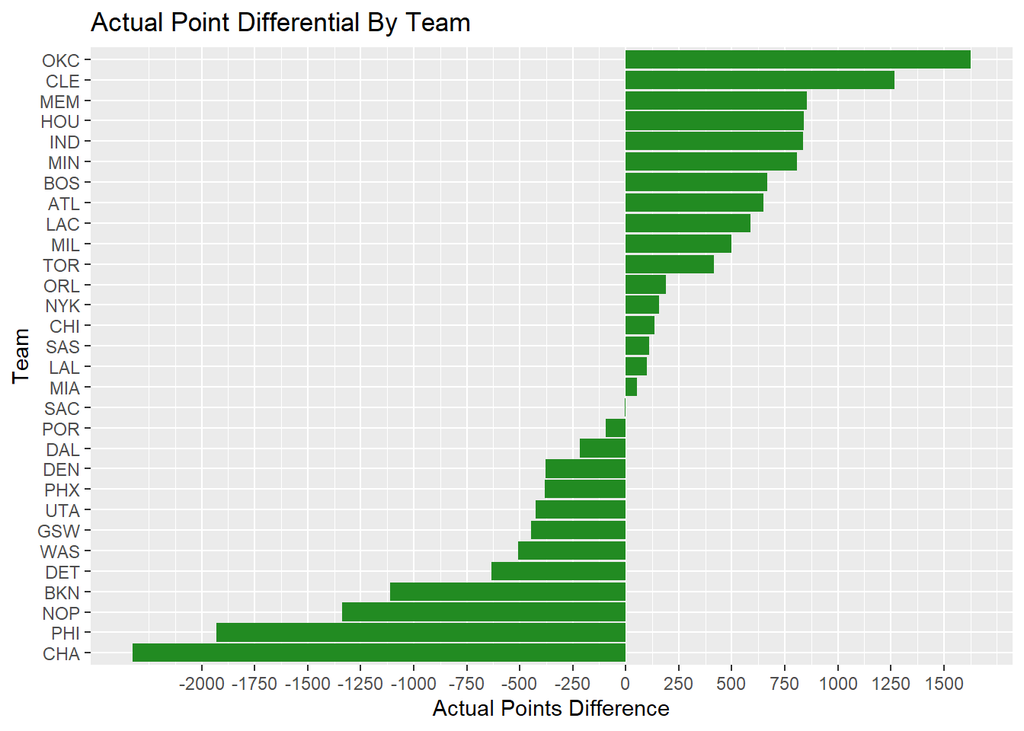

```r
# Plot 1: Actual Points Difference
ggplot(team_stats, aes(x = reorder(TEAM_NAME, POINTS_DIFFERENCE), y = POINTS_DIFFERENCE)) +
    geom_col(fill = "forestgreen") + coord_flip() +
  scale_y_continuous(breaks = seq(-2000, 1500, 250)) +
    labs(title = "Actual Point Differential By Team", x = "Team", y = "Actual Points Difference", x = NULL)
```

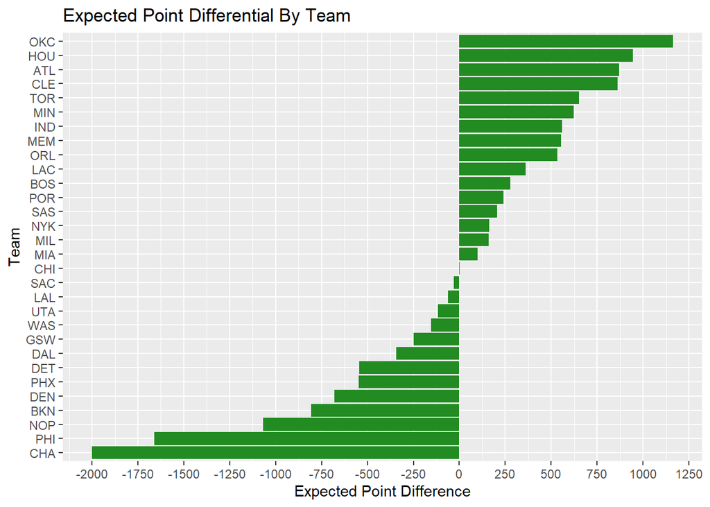

```r
  # Plot 2: Expected Points Difference
ggplot(team_stats, aes(x = reorder(TEAM_NAME, EXPECTED_POINTS_DIFFERENCE), y = EXPECTED_POINTS_DIFFERENCE)) + coord_flip() +
  scale_y_continuous(breaks = seq(-2000, 1500, 250)) +
    geom_col(fill = "forestgreen") +
    labs(title = "Expected Point Differential By Team", x = "Team", y = "Expected Point Difference", x = NULL)
```

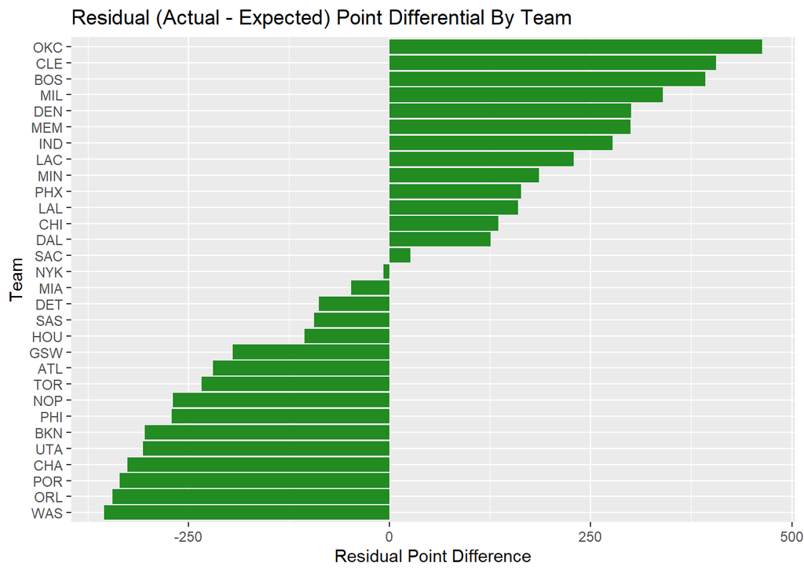

```r
# Plot 2: Residual Points Difference
ggplot(team_stats_final, aes(x = reorder(TEAM_NAME, RESIDUAL_POINT_DIFF), y = RESIDUAL_POINT_DIFF)) + coord_flip() +
  scale_y_continuous(breaks = seq(-2000, 1500, 250)) +
    geom_col(fill = "forestgreen") +
    labs(title = "Residual (Actual - Expected) Point Differential By Team", x = "Team", y = "Residual Point Difference", x = NULL)
```

## Application to the Question

Recall the initial problem was to determine which model of computing expected points was “best”. We attempt to answer this dilemma by assessing which models respond the best to statistical testing metrics. Here, we employ the metrics defined earlier in the presentation

The missclassification rate and log-loss was calculated for each model.

```r
model1_mis = misclass(scored_shots_2.0$SHOT_MADE_FLAG, scored_shots_2.0$predicted_made)
model2_mis = misclass(shots_2025_xp2$SHOT_MADE_FLAG, shots_2025_xp2$PREDICTED_MADE)
model3_mis = misclass(shots_2025_with_predicted_shots$SHOT_MADE_FLAG, shots_2025_with_predicted_shots$PREDICTED_MADE)
cat("Model1 Misclass Rate", round(mean(model1_mis), digits = 3), "\n")
```

```
## Model1 Misclass Rate 0.377
```

```r
cat("Model2 Misclass Rate", round(mean(model2_mis), digits = 3), "\n")
```

```
## Model2 Misclass Rate 0.374
```

```r
cat("Model3 Misclass Rate", round(mean(model3_mis), digits = 3), "\n")
```

```
## Model3 Misclass Rate 0.149
```

```r
cat("Model 1 Logloss:", round(mean(results$mean_log_loss), digits = 3), "\n")
```

```
## Model 1 Logloss: 0.683
```

```r
cat("Model 2 Training Logloss:", round(mean(train_logloss2), digits = 3), "\n")
```

```
## Model 2 Training Logloss: 0.641
```

```r
cat("Model 2 Testing Logloss:", round(mean(test_logloss2), digits = 3), "\n")
```

```
## Model 2 Testing Logloss: 0.642
```

```r
cat("Model 3 Training Logloss:", round(mean(train_logloss), digits = 3), "\n")
```

```
## Model 3 Training Logloss: 0.401
```

```r
cat("Model 3 Testing Logloss:", round(mean(test_logloss), digits = 3), "\n")
```

```
## Model 3 Testing Logloss: 0.65
```

Each models application to observed NBA results was considered. A data frame consisting of the standings for the 24-25 season was created.

```r
nba_standings <- tribble(
  ~TEAM_NAME, ~W, ~L, ~WinPct,
  "CLE", 64, 18, 0.780,
  "BOS", 61, 21, 0.744,
  "NYK", 51, 31, 0.622,
  "IND", 50, 32, 0.610,
  "MIL", 48, 34, 0.585,
  "DET", 44, 38, 0.537,
  "ORL", 41, 41, 0.500,
  "ATL", 40, 42, 0.488,
  "CHI", 39, 43, 0.476,
  "MIA", 37, 45, 0.451,
  "TOR", 30, 52, 0.366,
  "BKN", 26, 56, 0.317,
  "PHI", 24, 58, 0.293,
  "CHA", 19, 63, 0.232,
  "WAS", 18, 64, 0.220,
  "OKC", 68, 14, 0.829,
  "HOU", 52, 30, 0.634,
  "LAL", 50, 32, 0.610,
  "DEN", 50, 32, 0.610,
  "LAC", 50, 32, 0.610,
  "MIN", 49, 33, 0.598,
  "GSW", 48, 34, 0.585,
  "MEM", 48, 34, 0.585,
  "SAC", 40, 42, 0.488,
  "DAL", 39, 43, 0.476,
  "PHX", 36, 46, 0.439,
  "POR", 36, 46, 0.439,
  "SAS", 34, 48, 0.415,
  "NOP", 21, 61, 0.256,
  "UTA", 17, 65, 0.207
) %>% mutate(Win_Rank = min_rank(desc(W)))
nba_standings
```

```
## # A tibble: 30 × 5
##    TEAM_NAME     W     L WinPct Win_Rank
##    <chr>     <dbl> <dbl>  <dbl>    <int>
##  1 CLE          64    18  0.78         2
##  2 BOS          61    21  0.744        3
##  3 NYK          51    31  0.622        5
##  4 IND          50    32  0.61         6
##  5 MIL          48    34  0.585       11
##  6 DET          44    38  0.537       14
##  7 ORL          41    41  0.5         15
##  8 ATL          40    42  0.488       16
##  9 CHI          39    43  0.476       18
## 10 MIA          37    45  0.451       20
## # ℹ 20 more rows
```

```r
team_model_rankings = list(
  nba_standings %>% select(TEAM_NAME, Win_Rank),
  Offense_and_Defense_rankings %>% select(TEAM_NAME, Rank_Model1),
  team_xp_combined2_rankings %>% select(TEAM_NAME, Rank_Model2),
  team_stats_rankings %>% select(TEAM_NAME, Rank_Model3)
) %>%
  reduce(full_join, by = "TEAM_NAME")
team_model_rankings
```

```
## # A tibble: 30 × 5
##    TEAM_NAME Win_Rank Rank_Model1 Rank_Model2 Rank_Model3
##    <chr>        <int>       <int>       <int>       <int>
##  1 CLE              2           5           5           4
##  2 BOS              3          13          13          11
##  3 NYK              5          15          15          14
##  4 IND              6           9           8           7
##  5 MIL             11          16          16          15
##  6 DET             14          24          24          24
##  7 ORL             15           7           6           9
##  8 ATL             16           3           3           3
##  9 CHI             18          17          18          17
## 10 MIA             20          14          14          16
## # ℹ 20 more rows
```

```r
standings1 = sqrt(mean((team_model_rankings$Win_Rank - team_model_rankings$Rank_Model1)^2))
standings2 = sqrt(mean((team_model_rankings$Win_Rank - team_model_rankings$Rank_Model2)^2))
standings3 = sqrt(mean((team_model_rankings$Win_Rank - team_model_rankings$Rank_Model3)^2))
```

The RMSE was then calculated in both the difference between the standings rankings and expected points differentials, as well as between the actual and expected points differentials themselves. The RMSE values for all models applied to NBA standings seemed to suggest that attempting to quantify win rankings as a function of a teams shots alone is questionable at best. On average, each teams expected point differential was 8 places away from their true wins ranking, suggesting that a more granular, game by game approach should be taken to predict win rankings.

```r
cat("Model1 Standings Root Mean Squared Error:", round(standings1, digits = 3), "\n")
```

```
## Model1 Standings Root Mean Squared Error: 8.862
```

```r
cat("Model2 Standings Root Mean Squared Error:", round(standings2, digits = 3), "\n")
```

```
## Model2 Standings Root Mean Squared Error: 8.641
```

```r
cat("Model3 Standings Root Mean Squared Error:", round(standings3, digits = 3), "\n")
```

```
## Model3 Standings Root Mean Squared Error: 8.149
```

However, different results transpired when calculating RMSE for each team’s expected points values. As even the Binning and Averaging model on average came within 295 total points of the true value, which is less then 3 games worth of points when considering the average points scored per game. This suggests that each model is at least reasonably accurate in computing theoretical probabilities, where a portion of the RMSE can potentially be explained by general over or under performance for certain shots in each model.

```r
model1_rmse = sqrt(mean(Expected_vs_Actual_2.0$residual^2))
model2_rmse = sqrt(mean(team_xp_scored2$RESIDUAL_TOTAL_POINTS^2))
model3_rmse = sqrt(mean(team_stats$POINTS_RESIDUAL^2))
```

```r
cat("Model1 Root Mean Squared Error:", round(model1_rmse, digits = 3), "\n")
```

```
## Model1 Root Mean Squared Error: 295.096
```

```r
cat("Model2 Root Mean Squared Error:", round(model2_rmse, digits = 3), "\n")
```

```
## Model2 Root Mean Squared Error: 278.31
```

```r
cat("Model3 Root Mean Squared Error:", round(model3_rmse, digits = 3), "\n")
```

```
## Model3 Root Mean Squared Error: 261.154
```

Additionally, a correlation coefficient was assessed on the team rankings for each model, and although each result proved that expected points difference was moderately correlated with win ranking, the Random Forest model proved again to outperform the others in terms of correlation.

```r
cor(team_model_rankings$Win_Rank, team_model_rankings$Rank_Model1)
```

```
## [1] 0.4881107
```

```r
cor(team_model_rankings$Win_Rank, team_model_rankings$Rank_Model2)
```

```
## [1] 0.5133766
```

```r
cor(team_model_rankings$Win_Rank, team_model_rankings$Rank_Model3)
```

```
## [1] 0.5673933
```

For the sake of curiosity and potential future considerations, expected points values and residuals were evaluated on a per 100 possession basis in an attempt to eliminate model bias for teams that play at a fast pace. Although not strongly implemented in this model, perhaps standardizing all statistics on a uniform possession basis may be able to quantify over and under expectation in a common metric for all teams, garnering a result applicable to all styles of play.

```r
team_stats_with_wins = left_join(team_stats, nba_standings, by = "TEAM_NAME") %>% mutate()
team_stats_with_wins
```

```
## # A tibble: 30 × 20
##    TEAM_NAME TOTAL_POINTS EXPECTED_TOTAL_POINTS   FGA POINTS_PER_100
##    <chr>            <dbl>                 <dbl> <int>          <dbl>
##  1 ATL               8219                 8408.  7528           109.
##  2 BKN               6039                 6296.  5800           104.
##  3 BOS               7732                 7468.  6867           113.
##  4 CHA               5244                 5587.  5192           101.
##  5 CHI               7948                 8010.  7176           111.
##  6 CLE               8519                 8318.  7351           116.
##  7 DAL               7331                 7315.  6711           109.
##  8 DEN               7386                 7060.  6363           116.
##  9 DET               6761                 6810.  6235           108.
## 10 GSW               6827                 6855.  6352           107.
## # ℹ 20 more rows
## # ℹ 15 more variables: EXPECTED_POINTS_PER_100 <dbl>,
## #   TOTAL_POINTS_ALLOWED <dbl>, EXPECTED_TOTAL_POINTS_ALLOWED <dbl>,
## #   FGA_ALLOWED <int>, POINTS_PER_100_ALLOWED <dbl>,
## #   EXPECTED_POINTS_PER_100_ALLOWED <dbl>, POINTS_DIFFERENCE <dbl>,
## #   EXPECTED_POINTS_DIFFERENCE <dbl>, PER_100_DIFFERENCE <dbl>,
## #   EXPECTED_PER_100_DIFFERENCE <dbl>, POINTS_RESIDUAL <dbl>, W <dbl>, …
```

```r
team_residual_stats = team_stats %>% mutate(
  TOTAL_POINTS_RESIDUAL = TOTAL_POINTS - EXPECTED_TOTAL_POINTS,
  POINTS_PER_100_RESIDUAL = POINTS_PER_100 - EXPECTED_POINTS_PER_100,
  TOTAL_POINTS_ALLOWED_RESIDUAL = TOTAL_POINTS_ALLOWED - EXPECTED_TOTAL_POINTS_ALLOWED,
  POINTS_DIFFERENCE_RESIDUAL = TOTAL_POINTS_RESIDUAL - TOTAL_POINTS_ALLOWED_RESIDUAL,
  POINTS_PER_100_ALLOWED_RESIDUAL = POINTS_PER_100_ALLOWED - EXPECTED_POINTS_PER_100_ALLOWED,
  POINTS_DIFFERENCE_PER_100_RESIDUAL = PER_100_DIFFERENCE - EXPECTED_PER_100_DIFFERENCE,
  POINTS_DIFFERENCE_RESIDUAL2 = POINTS_DIFFERENCE - EXPECTED_POINTS_DIFFERENCE) %>%  select(TEAM_NAME, TOTAL_POINTS_RESIDUAL, POINTS_PER_100_RESIDUAL, TOTAL_POINTS_ALLOWED_RESIDUAL, POINTS_PER_100_ALLOWED_RESIDUAL, POINTS_DIFFERENCE_PER_100_RESIDUAL)
team_residual_stats
```

```
## # A tibble: 30 × 6
##    TEAM_NAME TOTAL_POINTS_RESIDUAL POINTS_PER_100_RESID…¹ TOTAL_POINTS_ALLOWED…²
##    <chr>                     <dbl>                  <dbl>                  <dbl>
##  1 ATL                      -189.                  -2.52                    30.3
##  2 BKN                      -257.                  -4.43                    47.0
##  3 BOS                       264.                   3.85                  -128.
##  4 CHA                      -343.                  -6.60                   -16.9
##  5 CHI                       -61.5                 -0.857                 -197.
##  6 CLE                       201.                   2.73                  -206.
##  7 DAL                        16.1                  0.240                 -109.
##  8 DEN                       326.                   5.12                    25.7
##  9 DET                       -48.9                 -0.785                   38.7
## 10 GSW                       -28.4                 -0.447                  167.
## # ℹ 20 more rows
## # ℹ abbreviated names: ¹POINTS_PER_100_RESIDUAL, ²TOTAL_POINTS_ALLOWED_RESIDUAL
## # ℹ 2 more variables: POINTS_PER_100_ALLOWED_RESIDUAL <dbl>,
## #   POINTS_DIFFERENCE_PER_100_RESIDUAL <dbl>
```

## Limitations and Future Considerations

Although these models seem to track well with observed values, there are several considerable limitations that effect the potential output and applicability of the models.

The foremost limitation of the model is the lack of inclusion concerning free throws. For the 2024-25 season, 13.9% of all points scored came from free throws, a significant area. Although the Pythagorean Expectation attempts to remedy this lack of data, this statistic still fundamentally attempts to estimate outcomes where a significant part of that outcome is dependent on data we don’t have. Thus, we must not extend these results too far, as some teams score a higher percentage of their points as free throws than others, affecting expected points and therefore expected win values.

The method of comparing NBA Season totals to the expected difference in points scored and allowed may also be a flawed metric, especially when a method for computing expected wins at the game by game level exists. However this consideration can be set aside on the basis that free throws often decide individual games, yet another reason why including free throw data would prove useful.

Another consideration to be made is the amount of training and testing spits performed on the data set, as only a few validation could potentially lead to model bias and, However, given the enormous raw size of the data set, as well as there being an ample amount of shot data for each specific combination of shot, this problem is potentially less significant than it may seem.

A final consideration when evaluating the efficacy of the previous models is a potential of important features that could contribute to expected points per shot. Consider the StatsBombR XG models from lecture, and variables such as the number of defenders between the goalpost, the angle to the goal, and the number of defenders near the shooter. This same logic is easily extended to basketball shot data, as the following features could potentially have an impact on expected points.

1. Number (if any) of defenders contesting the shot attempt
2. Distance of defenders hand to ball release point
3. Time Remaining on Shot Clock
4. Angle of shooter to basket on jump shots
5. Score Differential

For example, the models may not be able to differentiate between a wide-open 25 foot three point shot with 15 seconds left on the shot clock compared to an attempt covered by two players with 0.5 seconds on the clock. These predictors would likely produce tighter estimates of the true expected points value, and if they were included in the model, it’s much more likely that teams that take shots associated with the “good” values of these categories would see a higher cumulative expected points total.

## Conclusions

```r
library(tibble)

library(tibble)

model_stats <- tribble(
  ~Model, ~"Standings RMSE", ~"Misclass Rate", ~"Shot RMSE", ~"Training Logloss",
  "Model 1", 8.862, 0.377, 295.096, 0.683,
  "Model 2", 8.641, 0.374, 278.310, 0.641,
  "Model 3", 8.149, 0.149, 261.154, 0.401
)
model_stats = as.data.frame(model_stats)
model_stats
```

```
##     Model Standings RMSE Misclass Rate Shot RMSE Training Logloss
## 1 Model 1          8.862         0.377   295.096            0.683
## 2 Model 2          8.641         0.374   278.310            0.641
## 3 Model 3          8.149         0.149   261.154            0.401
```